# 국가화재 정보시스템 재산피해 데이터 분석

소방빅데이터담당

### 1. 데이터 설명 및 분석목적

본 데이터는 최근 5년 (2016년 ~ 2020년) 동안의 화재조사 보고서 데이터로, 화재 건수인 행의 개수는 14723개이고, 열의 개수는 217개이다. 본 분석 보고서는 화재조사 시 산정된 재산피해액의 분포를 탐색하여 어떤 경우에 재산 피해금액이 달라지는지 알아보고, 그 결과를 향후 진행할 분석에 활용하는것에 목적이 있다.

화재조사 보고서에 입력된 데이터의 일부는 다음과 같다. 화재조사 보고서 데이터는 수치형, 문자형, 날짜형 데이터로 이루어져 있다.

```r
fire %>% head()
```

```
## # A tibble: 6 x 217
##    연번 조사서번호 긴급구조번호  사망  부상 `인명피해(명)소계`… 재산피해소계
##   <dbl> <chr>      <chr>        <dbl> <dbl>            <dbl>        <dbl>
## 1     1 160101024… QO4804710837     0     0                0           13
## 2     2 160101025… QO4804710844     0     0                0          433
## 3     3 160101073… QO4804710879     0     0                0         5737
## 4     4 160101110… QO4804710950     0     0                0          261
## 5     5 160101071… QO4804710980     0     0                0         8368
## 6     6 160101103… QO4804711262     0     0                0          451
## # … with 210 more variables: 시도본부 <chr>, 소방서 <fct>, `119안전센터` <chr>,
## #   `119지역대` <chr>, 화재발생년월일 <dttm>, `화재발생(년)` <dbl>,
## #   `화재발생(월)` <dbl>, `화재발생(일)` <dbl>, `화재발생(시)` <dbl>,
## #   `화재발생(분)` <dbl>, 요일 <chr>, 접수일시 <dttm>, 출동일시 <dttm>,
## #   도착일시 <dttm>, 초진일시 <dttm>, 완진일시 <dttm>, 귀소일시 <dttm>,
## #   출동소요시간 <time>, 화재진압시간 <time>, 시도 <chr>, 시군구 <chr>,
## #   읍면동 <chr>, 세부주소 <chr>, 도로명 <chr>, `건물층수(지상)` <dbl>,
## #   `건물층수(지하)` <dbl>, 발화층 <dbl>, 화재유형 <chr>,
## #   `소방서거리(㎞)` <dbl>, 안전센터거리 <dbl>, 지역대거리 <dbl>,
## #   발화열원 <chr>, 발화열원소분류 <chr>, 발화요인대분류 <chr>,
## #   발화요인소분류 <chr>, 최초착화물대분류 <chr>, 최초착화물소분류 <chr>,
## #   발화개요 <chr>, 발화관련기기대분류 <chr>, 발화관련기기소분류 <chr>,
## #   제조국가명 <chr>, 회사명 <chr>, 제품명 <chr>, `제품번호(고유번호)` <chr>,
## #   `제조일(년)` <chr>, 동력원대분류 <chr>, 동력원소분류 <chr>,
## #   연소확대물대 <chr>, 연소확대물소 <chr>, 연소확대사유 <chr>,
## #   이재세대수 <dbl>, `이재민(명)` <dbl>, 부동산 <dbl>, 동산 <dbl>,
## #   화재피해경감액 <dbl>, 부동산경감 <dbl>, 동산경감 <dbl>,
## #   `소실면적(㎡)` <dbl>, `전체소실건축구조물(동)` <dbl>,
## #   `전소건축구조물(동)` <dbl>, `반소건축구조물(동)` <dbl>,
## #   `부분소건축구조물(동)` <dbl>, `전체소실차량등(대)` <dbl>,
## #   `전소차량등(대)` <dbl>, `반소차량등(대)` <dbl>, `부분소차량등(대)` <dbl>,
## #   `인명구조(명)` <dbl>, `유도대피(명)` <dbl>, 소유자성별 <chr>,
## #   소유자나이 <dbl>, 점유자성별 <chr>, 점유자나이 <dbl>, 동원인력소계 <dbl>,
## #   소방동원명수 <dbl>, 의소대동원명수 <dbl>, 경찰동원명수 <dbl>,
## #   일반직동원명수 <dbl>, 군인동원명수 <dbl>, 전기가스유관기관동원명수 <dbl>,
## #   기타동원명수 <dbl>, 동원장비소계 <dbl>, 펌프물탱크 <dbl>,
## #   `고가(굴절)` <dbl>, 화학 <dbl>, 구조 <dbl>, 구급 <dbl>, 헬기 <dbl>,
## #   선박 <dbl>, 기타 <dbl>, `보험금액(천원)` <dbl>, 화재보험의무가입대상 <chr>,
## #   `보험금액(부동산)` <dbl>, `보험금액(동산)` <dbl>, 날씨 <chr>,
## #   `온도(℃)` <dbl>, 습도 <dbl>, 풍속 <chr>, 풍향 <chr>, 기상특보 <chr>,
## #   건물구조식 <chr>, …
```

### 2. 재산피해의 분포

재산피해 데이터는 천원 단위로 기록되어 있고, 최소 0천원 부터 최대 48.6억원 까지 기록되어 있으며, 재산피해 데이터의 분포를 시각화 형태로 나타내면 다음과 같다.

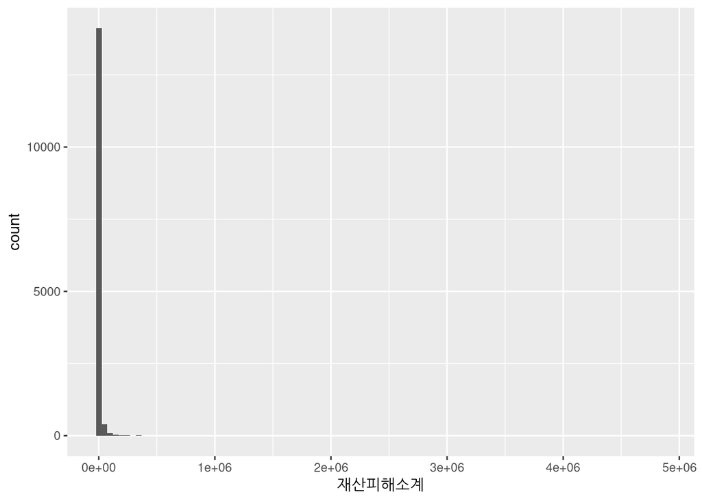

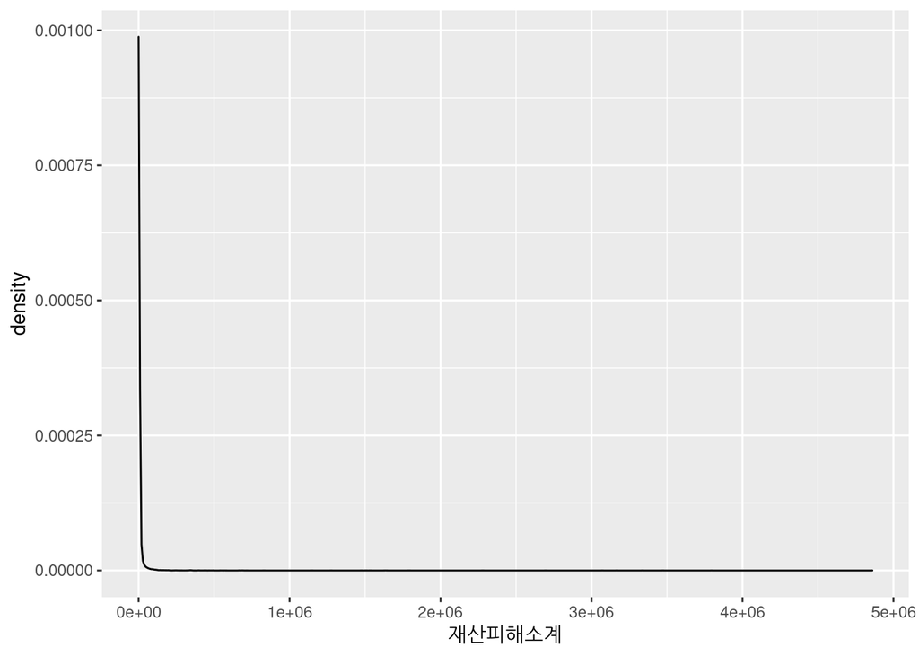

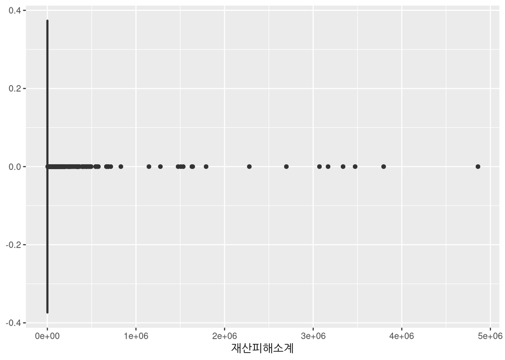

```r
# 1. 재산피해 히스토그램 ----
ggplot(fire, aes(x = 재산피해소계)) +
  geom_histogram(bins = 100)

# 2. 재산피해 밀도그림 ----
ggplot(fire, aes(x = 재산피해소계)) +
  geom_density()

# 3. 재산피해 상자그림 ----
ggplot(fire, aes(x = 재산피해소계)) +
  geom_boxplot()
```

재산 피해 데이터는 0근처에 많이 분포되어 있다는 것을 알 수 있다. 재산피해액을 백만원 단위로 변환하였을 때 금액대별 빈도는 다음 표와 같다. 0백만원대의 데이터가 9,120건 (61.9%)로 많은 비율을 차지한다.

```r
### 2-1-4. 백만원 단위로 변환하여 빈도와 비율 산출
fire %>%
  mutate(재산피해_백만원 = trunc(재산피해소계/1000)) %>%
  count(재산피해_백만원) %>%
  mutate(prop = round(n * 100 / sum(n),1))
```

```
## # A tibble: 218 x 3
##    재산피해_백만원     n  prop
##              <dbl> <int> <dbl>
##  1               0  9120  61.9
##  2               1  1406   9.5
##  3               2   749   5.1
##  4               3   549   3.7
##  5               4   430   2.9
##  6               5   301   2
##  7               6   220   1.5
##  8               7   198   1.3
##  9               8   177   1.2
## 10               9   216   1.5
## # … with 208 more rows
```

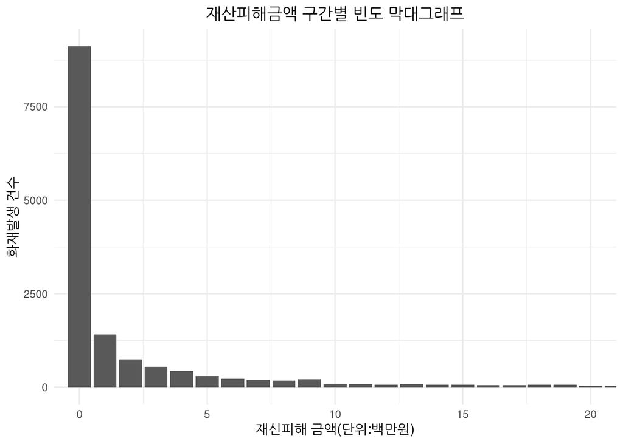

```r
fire %>%
  mutate(재산피해_백만원 = trunc(재산피해소계/1000)) %>%
  count(재산피해_백만원) %>%
  ggplot(aes(x = 재산피해_백만원, y = n)) +
  geom_bar(stat = 'identity') +
  theme_minimal() +
  coord_cartesian(xlim = c(0, 20)) +
  labs(title = "재산피해금액 구간별 빈도 막대그래프") +
  ylab("화재발생 건수") +
  xlab("재신피해 금액(단위:백만원)") +
  theme(plot.title = element_text(hjust = 0.5))
```

### 3. 재산피해와 연관성 있는 변수 탐색

#### 가. 화재유형별 재산피해액의 분포

화재 유형별 재산피해액의 분포는 다음과 같다. 화재 유형은 크게 6종으로 나뉘는데 건축구조물화재, 철도차량화재, 선박항공기화재, 위험물가스제조소등 화재, 임야화재, 기타(쓰레기)화재이다.

이와 같은 결과는 임의의 화재가 발생하였을 때 60% 의 화재는 1백만원 이하의 재산피해가 발생할 것으로 예상할 수 있고, 건축, 구조물 화재의 경우 50% 는 2백만원 이하의 재산 피해가 발생할 것으로 예상할 수 있다고 말할 수 있다.

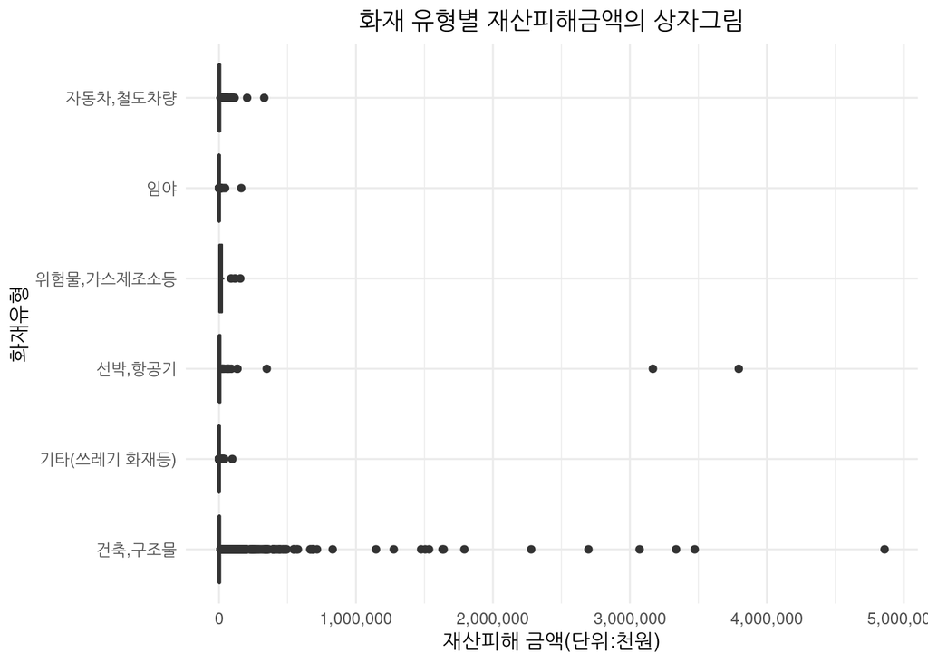

```r
# 1. 화재유형별 재산피해 상자그림 ----
fire %>%
  ggplot(aes(x = 화재유형, y = 재산피해소계)) +
  geom_boxplot() +
  coord_flip() +
  labs(title = "화재 유형별 재산피해금액의 상자그림") +
  ylab("재산피해 금액(단위:천원)") +
  theme_minimal() +
  theme(plot.title = element_text(hjust = 0.5)) +
  scale_y_continuous(labels=comma)
```

```r
# 2. 화재유형별 재산피해액 기초통계량 ----
fire %>%
  group_by(화재유형) %>%
  summarise(건수 = n(),
              재산피해평균 = round(mean(재산피해소계), 1),
              재산피해표준편차 = round(sd(재산피해소계), 1),
              `재산피해하위25%` = quantile(재산피해소계, 0.25),
              `재산피해하위50%` = quantile(재산피해소계, 0.50),
              `재산피해상위25%` = quantile(재산피해소계, 0.75), .groups = 'drop') %>%
  kable(caption = "화재유형별 재산피해액의 기초통계량",
        align = "lrrrrrr",
        digits = 1,
        format.args = list(big.mark = ",", scientific = FALSE))
```

화재유형별 재산피해액의 기초통계량

| 화재유형 | 건수 | 재산피해평균 | 재산피해표준편차 | 재산피해하위25% | 재산피해하위50% | 재산피해상위25% |
| --- | --- | --- | --- | --- | --- | --- |
| 건축,구조물 | 7,772 | 13,172.4 | 112,256.0 | 243.0 | 1,227.0 | 4,997.0 |
| 기타(쓰레기 화재등) | 4,283 | 342.0 | 2,333.5 | 0.0 | 9.0 | 107.0 |
| 선박,항공기 | 84 | 98,201.7 | 535,661.2 | 471.2 | 1,595.0 | 9,018.2 |
| 위험물,가스제조소등 | 16 | 29,396.6 | 47,458.9 | 2,535.8 | 8,078.5 | 21,925.2 |
| 임야 | 1,002 | 733.3 | 5,514.9 | 3.2 | 88.0 | 349.2 |
| 자동차,철도차량 | 1,566 | 5,615.0 | 14,442.2 | 607.8 | 1,908.0 | 5,390.0 |

##### 1) 건축,구조물 화재의 피해액 분포

화재 유형 중 건축, 구조물 화재가 가장 일반적인 형태의 화재로 재산피해 데이터의 특성을 일반화하기 쉬울 것으로 보고 건축, 구조물 화재에 대한 세부 분석을 실시하였다. 건축, 구조물 화재의 세부 장소 유형은 판매, 업무시설 등 9종으로 분류되고 있다.

장소 세부분류 중 주거 시설이 3,254건으로 가장 높으며, 평균 재산피해액은 4,937.8천원이다. 산업시설의 재산피해 평균은 31,524.3천원으로 가장 높은데 이는 10억 이상의 화재가 발생한 경우가 13건이 발생하여 평균 재산피해액이 가장 높게 나왔다.

이처럼 화재 유형과 건축, 구조물의 장소에 따라 재산피해액은 큰 차이를 보이며, 출동 도착 소요시간에 따른 재산피해금액의 변화 등 재산피해를 설명하기 위한 모델을 만든다면 더욱 세부적인 분석이 필요해 보인다.

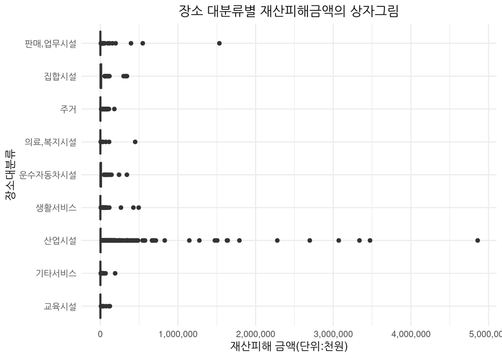

```r
fire %>%
  filter(화재유형 == "건축,구조물") %>%
  ggplot(aes(x = 장소대분류, y = 재산피해소계)) +
  geom_boxplot() +
  coord_flip() +
  labs(title = "장소 대분류별 재산피해금액의 상자그림") +
  ylab("재산피해 금액(단위:천원)") +
  theme_minimal() +
  theme(plot.title = element_text(hjust = 0.5)) +
  scale_y_continuous(labels=comma)
```

```r
fire %>%
  filter(화재유형 == "건축,구조물") %>%
  group_by(장소대분류) %>%
  summarise(건수 = n(),
              재산피해평균 = round(mean(재산피해소계), 1),
              재산피해표준편차 = round(sd(재산피해소계), 1),
              `재산피해하위25%` = quantile(재산피해소계, 0.25),
              `재산피해하위50%` = quantile(재산피해소계, 0.50),
              `재산피해상위25%` = quantile(재산피해소계, 0.75), .groups = 'drop') %>%
  arrange(-건수) %>%
  kable(caption = "장소 대분류별 재산피해액의 기초통계량",
        align = "lrrrrrr",
        digits = 1,
        format.args = list(big.mark = ",", scientific = FALSE))
```

장소 대분류별 재산피해액의 기초통계량

| 장소대분류 | 건수 | 재산피해평균 | 재산피해표준편차 | 재산피해하위25% | 재산피해하위50% | 재산피해상위25% |
| --- | --- | --- | --- | --- | --- | --- |
| 주거 | 3,254 | 4,937.8 | 11,032.1 | 156.2 | 1,014.5 | 4,856.2 |
| 산업시설 | 2,215 | 31,524.3 | 203,986.1 | 579.5 | 2,165.0 | 8,064.0 |
| 생활서비스 | 841 | 5,521.7 | 26,249.3 | 127.0 | 701.0 | 3,027.0 |
| 기타서비스 | 691 | 3,050.0 | 9,029.3 | 319.0 | 1,060.0 | 2,904.5 |
| 판매,업무시설 | 450 | 10,452.8 | 80,076.9 | 146.2 | 700.0 | 3,420.0 |
| 집합시설 | 102 | 21,680.9 | 57,044.6 | 510.2 | 3,086.5 | 17,369.0 |
| 의료,복지시설 | 90 | 9,066.1 | 49,054.7 | 103.2 | 624.0 | 2,215.0 |
| 교육시설 | 65 | 8,317.6 | 22,822.0 | 247.0 | 954.0 | 3,510.0 |
| 운수자동차시설 | 64 | 22,797.2 | 57,416.6 | 546.2 | 1,914.0 | 15,186.0 |

###### 가) 주거시설 화재의 피해액 분포

주거시설은 단독주택, 공동주택, 기타주택 3종으로 분류되고 단독 주택이 2,281건으로 가장 많은 비율을 차지하고, 공동주택, 기타주택 순으로 발생하였다. 평균 재산 피해금액은 단독주택이 5,723천원, 기타 주택이 4,536천원, 공동주택이 2,798천원이다.

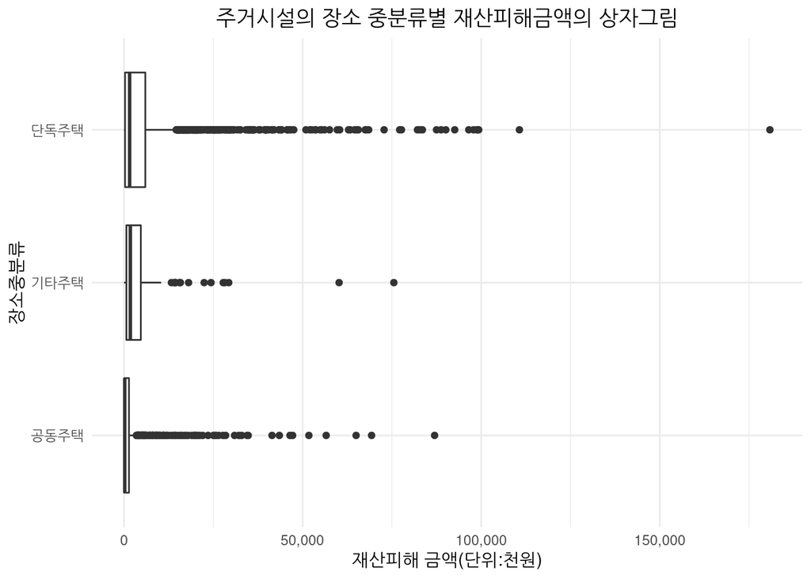

```r
fire %>%
  filter(화재유형 == "건축,구조물") %>%
  filter(장소대분류 == "주거") %>%
  ggplot(aes(x = 장소중분류, y = 재산피해소계)) +
  geom_boxplot() +
  coord_flip() +
  labs(title = "주거시설의 장소 중분류별 재산피해금액의 상자그림") +
  ylab("재산피해 금액(단위:천원)") +
  theme_minimal() +
  theme(plot.title = element_text(hjust = 0.5)) +
  scale_y_continuous(labels=comma)
```

```r
fire %>%
  filter(화재유형 == "건축,구조물") %>%
  filter(장소대분류 == "주거") %>%
  group_by(장소중분류) %>%
  summarise(건수 = n(),
              재산피해평균 = round(mean(재산피해소계), 1),
              재산피해표준편차 = round(sd(재산피해소계), 1),
              `재산피해하위25%` = quantile(재산피해소계, 0.25),
              `재산피해하위50%` = quantile(재산피해소계, 0.50),
              `재산피해상위25%` = quantile(재산피해소계, 0.75), .groups = 'drop') %>%
  arrange(-건수) %>%
  kable(caption = "주거시설의 장소 중분류별 재산피해액의 기초통계량",
        align = "lrrrrrr",
        digits = 1,
        format.args = list(big.mark = ",", scientific = FALSE))
```

주거시설의 장소 중분류별 재산피해액의 기초통계량

| 장소중분류 | 건수 | 재산피해평균 | 재산피해표준편차 | 재산피해하위25% | 재산피해하위50% | 재산피해상위25% |
| --- | --- | --- | --- | --- | --- | --- |
| 단독주택 | 2,281 | 5,723.8 | 12,013.8 | 280.0 | 1,570.0 | 5,954 |
| 공동주택 | 807 | 2,798.6 | 7,775.1 | 28.0 | 199.0 | 1,383 |
| 기타주택 | 166 | 4,536.7 | 8,871.5 | 645.5 | 1,761.5 | 4,701 |

###### 나) 산업시설 화재의 피해액 분포

산업시설 화재 중 발생 건수는 공장시설, 동식물시설, 창고시설 순으로 발생하였고, 평균 재산피해는 발전시설이 389,028.5천원으로 가장 크게 나타났고, 공장 화재의 평균도 40,399천원으로 주거 시설의 평균 피해액보다 높게 나타남.

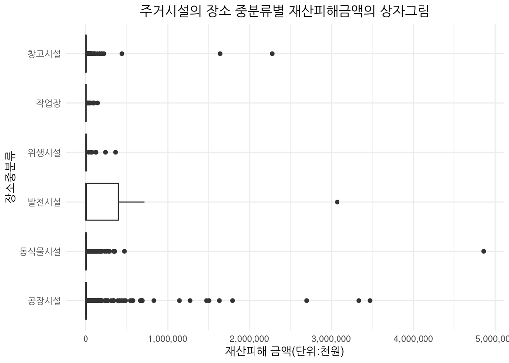

```r
fire %>%
  filter(화재유형 == "건축,구조물") %>%
  filter(장소대분류 == "산업시설") %>%
  ggplot(aes(x = 장소중분류, y = 재산피해소계)) +
  geom_boxplot() +
  coord_flip() +
  labs(title = "주거시설의 장소 중분류별 재산피해금액의 상자그림") +
  ylab("재산피해 금액(단위:천원)") +
  theme_minimal() +
  theme(plot.title = element_text(hjust = 0.5)) +
  scale_y_continuous(labels=comma)
```

```r
fire %>%
  filter(화재유형 == "건축,구조물") %>%
  filter(장소대분류 == "산업시설") %>%
  group_by(장소중분류) %>%
  summarise(건수 = n(),
              재산피해평균 = round(mean(재산피해소계), 1),
              재산피해표준편차 = round(sd(재산피해소계), 1),
              `재산피해하위25%` = quantile(재산피해소계, 0.25),
              `재산피해하위50%` = quantile(재산피해소계, 0.50),
              `재산피해상위25%` = quantile(재산피해소계, 0.75), .groups = 'drop') %>%
  arrange(-건수) %>%
  kable(caption = "주거시설의 장소 중분류별 재산피해액의 기초통계량",
        align = "lrrrrrr",
        digits = 1,
        format.args = list(big.mark = ",", scientific = FALSE))
```

| 장소중분류 | 건수 | 재산피해평균 | 재산피해표준편차 | 재산피해하위25% | 재산피해하위50% | 재산피해상위25% |
| --- | --- | --- | --- | --- | --- | --- |
| 공장시설 | 983 | 40,399.7 | 222,519.0 | 545.0 | 2,293.0 | 9,081.5 |
| 동식물시설 | 622 | 23,449.0 | 199,706.6 | 655.5 | 2,288.5 | 8,171.8 |
| 창고시설 | 478 | 18,558.5 | 131,613.5 | 604.8 | 1,960.5 | 6,056.5 |
| 작업장 | 73 | 10,886.7 | 26,457.9 | 369.0 | 1,245.0 | 5,888.0 |
| 위생시설 | 47 | 25,407.0 | 66,990.8 | 582.0 | 1,646.0 | 12,973.0 |
| 발전시설 | 12 | 389,028.5 | 876,473.7 | 1,410.2 | 2,599.0 | 398,001.2 |

###### 다) 생활서비스 화재의 피해액 분포

생활서비스 시설은 음식점이 562건으로 가장 많았고, 음식점의 평균 재산피해금액은 5,755천원으로 단독주택과 (5,723천원) 비슷한 수준임.

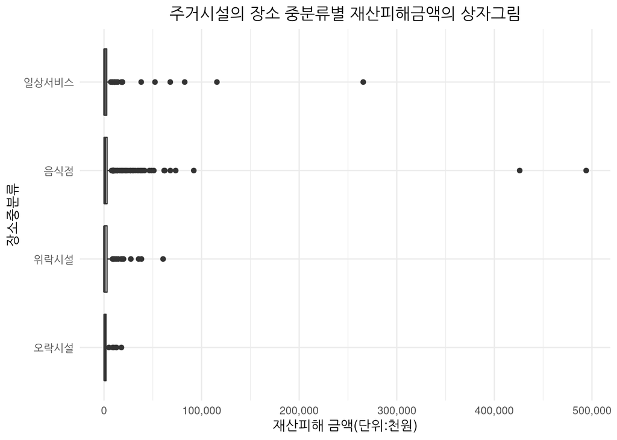

```r
fire %>%
  filter(화재유형 == "건축,구조물") %>%
  filter(장소대분류 == "생활서비스") %>%
  ggplot(aes(x = 장소중분류, y = 재산피해소계)) +
  geom_boxplot() +
  coord_flip() +
  labs(title = "주거시설의 장소 중분류별 재산피해금액의 상자그림") +
  ylab("재산피해 금액(단위:천원)") +
  theme_minimal() +
  theme(plot.title = element_text(hjust = 0.5)) +
  scale_y_continuous(labels=comma)
```

```r
fire %>%
  filter(화재유형 == "건축,구조물") %>%
  filter(장소대분류 == "생활서비스") %>%
  group_by(장소중분류) %>%
  summarise(건수 = n(),
              재산피해평균 = round(mean(재산피해소계), 1),
              재산피해표준편차 = round(sd(재산피해소계), 1),
              `재산피해하위25%` = quantile(재산피해소계, 0.25),
              `재산피해하위50%` = quantile(재산피해소계, 0.50),
              `재산피해상위25%` = quantile(재산피해소계, 0.75), .groups = 'drop') %>%
  arrange(-건수) %>%
  kable(caption = "주거시설의 장소 중분류별 재산피해액의 기초통계량",
        align = "lrrrrrr",
        digits = 1,
        format.args = list(big.mark = ",", scientific = FALSE))
```

| 장소중분류 | 건수 | 재산피해평균 | 재산피해표준편차 | 재산피해하위25% | 재산피해하위50% | 재산피해상위25% |
| --- | --- | --- | --- | --- | --- | --- |
| 음식점 | 562 | 5,755.1 | 29,036.6 | 146.0 | 772.5 | 3,148.8 |
| 일상서비스 | 174 | 5,650.6 | 23,717.9 | 69.5 | 543.0 | 2,776.5 |
| 위락시설 | 68 | 4,896.3 | 10,526.7 | 168.0 | 412.5 | 3,111.5 |
| 오락시설 | 37 | 2,519.6 | 4,261.4 | 155.0 | 745.0 | 2,024.0 |

##### 2) 임야, 기타 화재의 피해액 분포

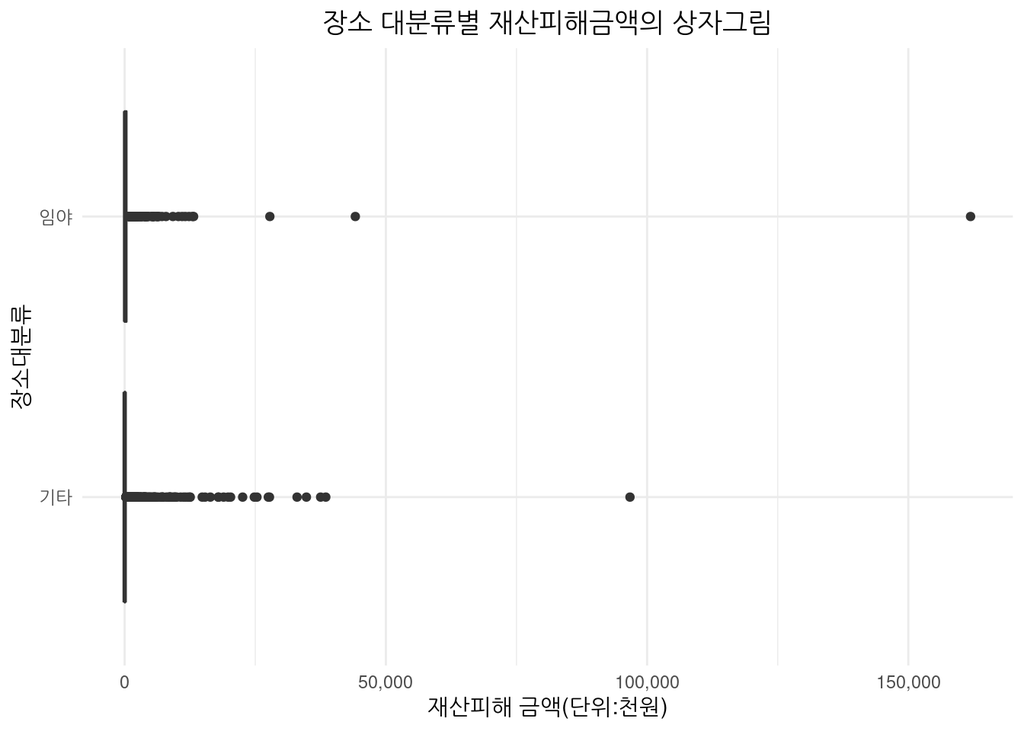

```r
fire %>%
  filter(화재유형 %in% c("임야", "기타(쓰레기 화재등)")) %>%
  ggplot(aes(x = 장소대분류, y = 재산피해소계)) +
  geom_boxplot() +
  coord_flip() +
  labs(title = "장소 대분류별 재산피해금액의 상자그림") +
  ylab("재산피해 금액(단위:천원)") +
  theme_minimal() +
  theme(plot.title = element_text(hjust = 0.5)) +
  scale_y_continuous(labels=comma)
```

```r
fire %>%
  filter(화재유형 %in% c("임야", "기타(쓰레기 화재등)")) %>%
  group_by(장소대분류) %>%
  summarise(건수 = n(),
              재산피해평균 = round(mean(재산피해소계), 1),
              재산피해표준편차 = round(sd(재산피해소계), 1),
              `재산피해하위25%` = quantile(재산피해소계, 0.25),
              `재산피해하위50%` = quantile(재산피해소계, 0.50),
              `재산피해상위25%` = quantile(재산피해소계, 0.75), .groups = 'drop') %>%
  arrange(-건수) %>%
  kable(caption = "장소 대분류별 재산피해액의 기초통계량",
        align = "lrrrrrr",
        digits = 1,
        format.args = list(big.mark = ",", scientific = FALSE))
```

장소 대분류별 재산피해액의 기초통계량

| 장소대분류 | 건수 | 재산피해평균 | 재산피해표준편차 | 재산피해하위25% | 재산피해하위50% | 재산피해상위25% |
| --- | --- | --- | --- | --- | --- | --- |
| 기타 | 4,283 | 342.0 | 2,333.5 | 0.0 | 9 | 107.0 |
| 임야 | 1,002 | 733.3 | 5,514.9 | 3.2 | 88 | 349.2 |

##### 3) 차량 등 화재의 피해액 분포

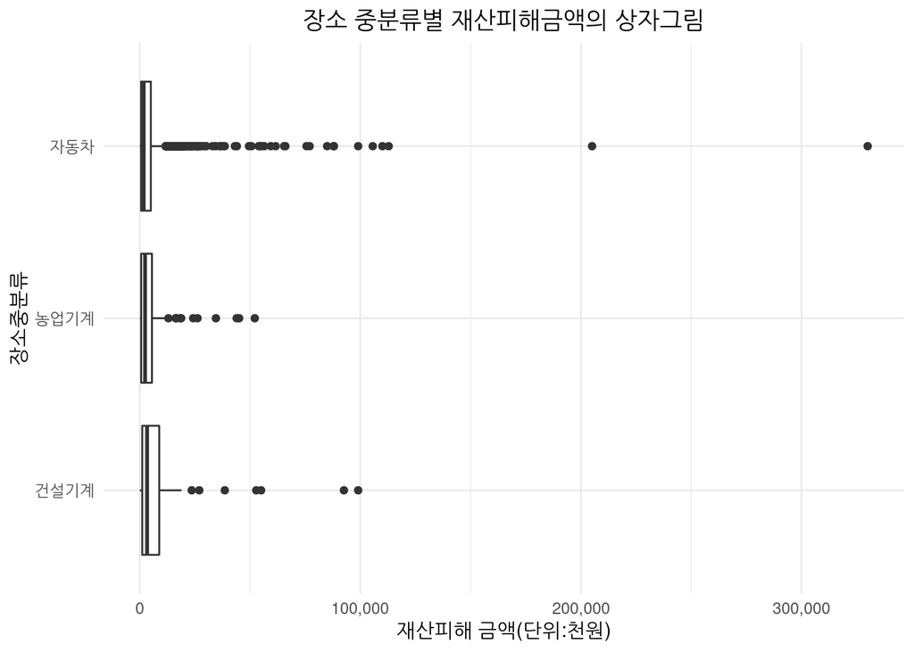

```r
fire %>%
  filter(화재유형 == "자동차,철도차량") %>%
  ggplot(aes(x = 장소중분류, y = 재산피해소계)) +
  geom_boxplot() +
  coord_flip() +
  labs(title = "장소 중분류별 재산피해금액의 상자그림") +
  ylab("재산피해 금액(단위:천원)") +
  theme_minimal() +
  theme(plot.title = element_text(hjust = 0.5)) +
  scale_y_continuous(labels=comma)
```

```r
fire %>%
  filter(화재유형 == "자동차,철도차량") %>%
  group_by(장소중분류) %>%
  summarise(건수 = n(),
              재산피해평균 = round(mean(재산피해소계), 1),
              재산피해표준편차 = round(sd(재산피해소계), 1),
              `재산피해하위25%` = quantile(재산피해소계, 0.25),
              `재산피해하위50%` = quantile(재산피해소계, 0.50),
              `재산피해상위25%` = quantile(재산피해소계, 0.75), .groups = 'drop') %>%
  arrange(-건수) %>%
  kable(caption = "장소 중분류별 재산피해액의 기초통계량",
        align = "lrrrrrr",
        digits = 1,
        format.args = list(big.mark = ",", scientific = FALSE))
```

장소 중분류별 재산피해액의 기초통계량

| 장소중분류 | 건수 | 재산피해평균 | 재산피해표준편차 | 재산피해하위25% | 재산피해하위50% | 재산피해상위25% |
| --- | --- | --- | --- | --- | --- | --- |
| 자동차 | 1,388 | 5,366.5 | 14,524.5 | 586 | 1,760 | 5,005 |
| 건설기계 | 109 | 8,233.8 | 15,094.9 | 1,100 | 3,300 | 8,800 |
| 농업기계 | 69 | 6,475.6 | 11,066.2 | 616 | 2,377 | 5,500 |

#### 나. 화재원인별 재산피해액의 분포

재산 피해액의 분포는 화재 원인별로 다른 양상을 보이는데, 미상, 화학적 요인, 방화일때 평균 1천만원 이상으로 나타났다. 원인 미상의 화재에서는 원인을 알 수 없을 정도로 소실정도가 심하여 재산피해가 높게 나타난 것으로 볼 수 있고, 방화나 화학적 요인에서는 급격한 연소 확대가 수반되는 특징이 있기 때문으로 생각된다.

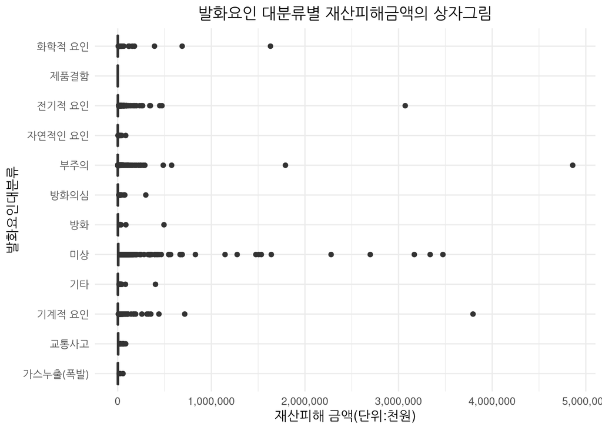

```r
# 화재원인별 재산피해 상자그림 ----
fire %>%
  ggplot(aes(x = 발화요인대분류, y = 재산피해소계)) +
  geom_boxplot() +
  coord_flip() +
  labs(title = "발화요인 대분류별 재산피해금액의 상자그림") +
  ylab("재산피해 금액(단위:천원)") +
  theme_minimal() +
  theme(plot.title = element_text(hjust = 0.5)) +
  scale_y_continuous(labels=comma)
```

```r
# 화재원인별 재산피해액 기초통계량 ----
fire %>%
  group_by(발화요인대분류) %>%
  summarise(건수 = n(),
              재산피해평균 = round(mean(재산피해소계), 1),
              재산피해표준편차 = round(sd(재산피해소계), 1),
              `재산피해하위25%` = quantile(재산피해소계, 0.25),
              `재산피해하위50%` = quantile(재산피해소계, 0.50),
              `재산피해상위25%` = quantile(재산피해소계, 0.75), .groups = 'drop') %>%
  arrange(-건수) %>%
  kable(caption = "발화요인 대분류별 재산피해액의 기초통계량",
        align = "lrrrrrr",
        digits = 1,
        format.args = list(big.mark = ",", scientific = FALSE))
```

발화요인 대분류별 재산피해액의 기초통계량

| 발화요인대분류 | 건수 | 재산피해평균 | 재산피해표준편차 | 재산피해하위25% | 재산피해하위50% | 재산피해상위25% |
| --- | --- | --- | --- | --- | --- | --- |
| 부주의 | 7,927 | 2,680.7 | 59,519.9 | 1.0 | 77.0 | 704.0 |
| 전기적 요인 | 2,713 | 7,404.3 | 63,172.1 | 228.0 | 1,100.0 | 4,291.0 |
| 미상 | 1,930 | 30,834.9 | 181,663.1 | 919.0 | 3,925.0 | 12,209.5 |
| 기계적 요인 | 1,345 | 9,190.4 | 107,937.2 | 308.0 | 1,100.0 | 3,784.0 |
| 화학적 요인 | 193 | 20,640.0 | 131,505.5 | 68.0 | 605.0 | 2,499.0 |
| 교통사고 | 155 | 8,176.0 | 12,423.6 | 1,050.5 | 3,850.0 | 9,900.0 |
| 기타 | 115 | 8,857.8 | 38,695.9 | 125.5 | 1,192.0 | 5,123.5 |
| 방화 | 114 | 10,375.9 | 47,012.1 | 111.5 | 1,188.5 | 7,737.0 |
| 방화의심 | 109 | 8,280.4 | 30,558.1 | 78.0 | 833.0 | 4,950.0 |
| 자연적인 요인 | 85 | 3,899.2 | 11,381.6 | 55.0 | 332.0 | 1,604.0 |
| 가스누출(폭발) | 34 | 5,497.7 | 10,756.1 | 151.0 | 1,242.0 | 6,501.5 |
| 제품결함 | 3 | 1,413.3 | 2,170.7 | 161.0 | 243.0 | 2,080.5 |

###### 1) 부주의 화재의 피해액 분포

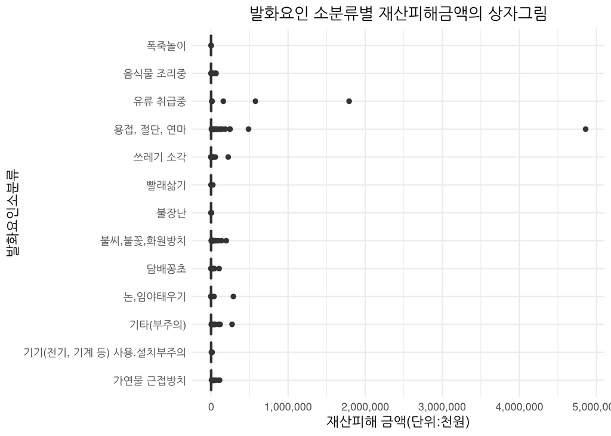

```r
# 화재원인별 재산피해 상자그림 ----
fire %>%
  filter(발화요인대분류 == "부주의") %>%
  ggplot(aes(x = 발화요인소분류, y = 재산피해소계)) +
  geom_boxplot() +
  coord_flip() +
  labs(title = "발화요인 소분류별 재산피해금액의 상자그림") +
  ylab("재산피해 금액(단위:천원)") +
  theme_minimal() +
  theme(plot.title = element_text(hjust = 0.5)) +
  scale_y_continuous(labels=comma)
```

```r
# 화재원인별 재산피해액 기초통계량 ----
fire %>%
  filter(발화요인대분류 == "부주의") %>%
  group_by(발화요인소분류) %>%
  summarise(건수 = n(),
              재산피해평균 = round(mean(재산피해소계), 1),
              재산피해표준편차 = round(sd(재산피해소계), 1),
              `재산피해하위25%` = quantile(재산피해소계, 0.25),
              `재산피해하위50%` = quantile(재산피해소계, 0.50),
              `재산피해상위25%` = quantile(재산피해소계, 0.75), .groups = 'drop') %>%
  arrange(-건수) %>%
  kable(caption = "발화요인 소분류별 재산피해액의 기초통계량",
        align = "lrrrrrr",
        digits = 1,
        format.args = list(big.mark = ",", scientific = FALSE))
```

발화요인 소분류별 재산피해액의 기초통계량

| 발화요인소분류 | 건수 | 재산피해평균 | 재산피해표준편차 | 재산피해하위25% | 재산피해하위50% | 재산피해상위25% |
| --- | --- | --- | --- | --- | --- | --- |
| 쓰레기 소각 | 2,169 | 509.5 | 5,174.3 | 0.0 | 5.0 | 110.0 |
| 담배꽁초 | 1,489 | 793.2 | 3,546.3 | 6.0 | 90.0 | 484.0 |
| 불씨,불꽃,화원방치 | 1,348 | 2,582.8 | 9,046.3 | 55.0 | 401.0 | 1,803.0 |
| 음식물 조리중 | 765 | 1,537.3 | 5,268.9 | 11.0 | 55.0 | 746.0 |
| 논,임야태우기 | 602 | 746.8 | 11,924.7 | 0.0 | 1.0 | 74.2 |
| 기타(부주의) | 494 | 3,419.1 | 15,166.0 | 11.0 | 223.0 | 1,671.2 |
| 용접, 절단, 연마 | 465 | 16,898.8 | 227,254.6 | 77.0 | 535.0 | 2,314.0 |
| 가연물 근접방치 | 419 | 3,819.0 | 9,869.8 | 203.5 | 991.0 | 3,639.0 |
| 불장난 | 69 | 275.0 | 837.4 | 0.0 | 18.0 | 100.0 |
| 빨래삶기 | 33 | 933.3 | 4,104.2 | 5.0 | 17.0 | 58.0 |
| 유류 취급중 | 32 | 81,207.7 | 328,995.9 | 509.5 | 915.5 | 3,991.0 |
| 기기(전기, 기계 등) 사용.설치부주의 | 23 | 2,558.7 | 3,929.1 | 331.5 | 917.0 | 1,654.5 |
| 폭죽놀이 | 19 | 123.1 | 285.9 | 0.0 | 0.0 | 41.0 |

###### 2) 전기적 요인 화재의 피해액 분포

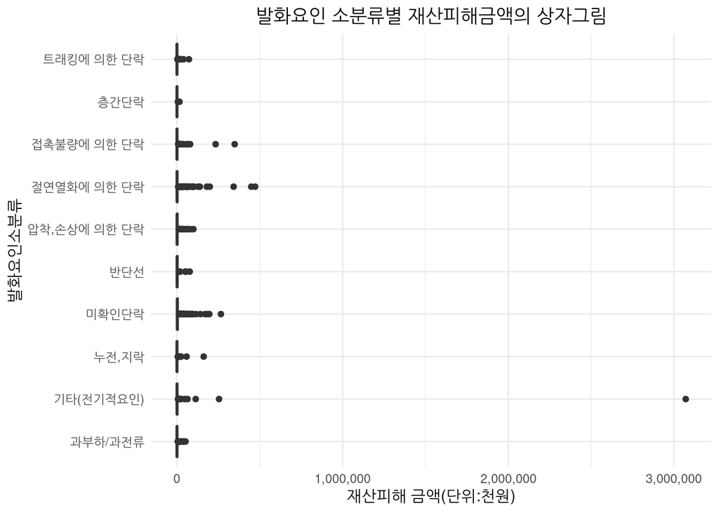

```r
# 화재원인별 재산피해 상자그림 ----
fire %>%
  filter(발화요인대분류 == "전기적 요인") %>%
  ggplot(aes(x = 발화요인소분류, y = 재산피해소계)) +
  geom_boxplot() +
  coord_flip() +
  labs(title = "발화요인 소분류별 재산피해금액의 상자그림") +
  ylab("재산피해 금액(단위:천원)") +
  theme_minimal() +
  theme(plot.title = element_text(hjust = 0.5)) +
  scale_y_continuous(labels=comma)
```

```r
# 화재원인별 재산피해액 기초통계량 ----
fire %>%
  filter(발화요인대분류 == "전기적 요인") %>%
  group_by(발화요인소분류) %>%
  summarise(건수 = n(),
              재산피해평균 = round(mean(재산피해소계), 1),
              재산피해표준편차 = round(sd(재산피해소계), 1),
              `재산피해하위25%` = quantile(재산피해소계, 0.25),
              `재산피해하위50%` = quantile(재산피해소계, 0.50),
              `재산피해상위25%` = quantile(재산피해소계, 0.75), .groups = 'drop') %>%
  arrange(-건수) %>%
  kable(caption = "발화요인 소분류별 재산피해액의 기초통계량",
        align = "lrrrrrr",
        digits = 1,
        format.args = list(big.mark = ",", scientific = FALSE))
```

발화요인 소분류별 재산피해액의 기초통계량

| 발화요인소분류 | 건수 | 재산피해평균 | 재산피해표준편차 | 재산피해하위25% | 재산피해하위50% | 재산피해상위25% |
| --- | --- | --- | --- | --- | --- | --- |
| 절연열화에 의한 단락 | 766 | 7,204.2 | 31,026.8 | 171.0 | 1,012.5 | 3,657.2 |
| 미확인단락 | 721 | 8,196.9 | 20,780.4 | 576.0 | 2,310.0 | 7,092.0 |
| 과부하/과전류 | 317 | 2,786.9 | 6,081.8 | 191.0 | 693.0 | 2,619.0 |
| 트래킹에 의한 단락 | 217 | 2,272.7 | 6,573.1 | 110.0 | 484.0 | 1,393.0 |
| 접촉불량에 의한 단락 | 212 | 7,254.9 | 30,688.8 | 116.8 | 646.0 | 3,229.5 |
| 압착,손상에 의한 단락 | 190 | 5,639.2 | 13,267.7 | 208.0 | 1,190.0 | 4,848.8 |
| 기타(전기적요인) | 107 | 35,818.4 | 297,469.0 | 275.0 | 994.0 | 2,775.0 |
| 누전,지락 | 96 | 4,249.3 | 17,693.1 | 186.8 | 539.0 | 1,919.0 |
| 반단선 | 70 | 5,699.9 | 12,723.3 | 366.5 | 1,269.5 | 5,319.2 |
| 층간단락 | 17 | 1,995.3 | 3,839.2 | 110.0 | 563.0 | 2,181.0 |

###### 3) 미상 화재의 피해액 분포

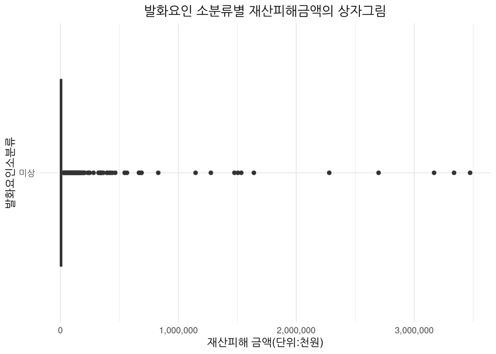

```r
# 화재원인별 재산피해 상자그림 ----
fire %>%
  filter(발화요인대분류 == "미상") %>%
  ggplot(aes(x = 발화요인소분류, y = 재산피해소계)) +
  geom_boxplot() +
  coord_flip() +
  labs(title = "발화요인 소분류별 재산피해금액의 상자그림") +
  ylab("재산피해 금액(단위:천원)") +
  theme_minimal() +
  theme(plot.title = element_text(hjust = 0.5)) +
  scale_y_continuous(labels=comma)
```

```r
# 화재원인별 재산피해액 기초통계량 ----
fire %>%
  filter(발화요인대분류 == "미상") %>%
  group_by(발화요인소분류) %>%
  summarise(건수 = n(),
              재산피해평균 = round(mean(재산피해소계), 1),
              재산피해표준편차 = round(sd(재산피해소계), 1),
              `재산피해하위25%` = quantile(재산피해소계, 0.25),
              `재산피해하위50%` = quantile(재산피해소계, 0.50),
              `재산피해상위25%` = quantile(재산피해소계, 0.75), .groups = 'drop') %>%
  arrange(-건수) %>%
  kable(caption = "발화요인 소분류별 재산피해액의 기초통계량",
        align = "lrrrrrr",
        digits = 1,
        format.args = list(big.mark = ",", scientific = FALSE))
```

발화요인 소분류별 재산피해액의 기초통계량

| 발화요인소분류 | 건수 | 재산피해평균 | 재산피해표준편차 | 재산피해하위25% | 재산피해하위50% | 재산피해상위25% |
| --- | --- | --- | --- | --- | --- | --- |
| 미상 | 1,930 | 30,834.9 | 181,663.1 | 919 | 3,925 | 12,209.5 |

###### 4) 기계적 요인 화재의 피해액 분포

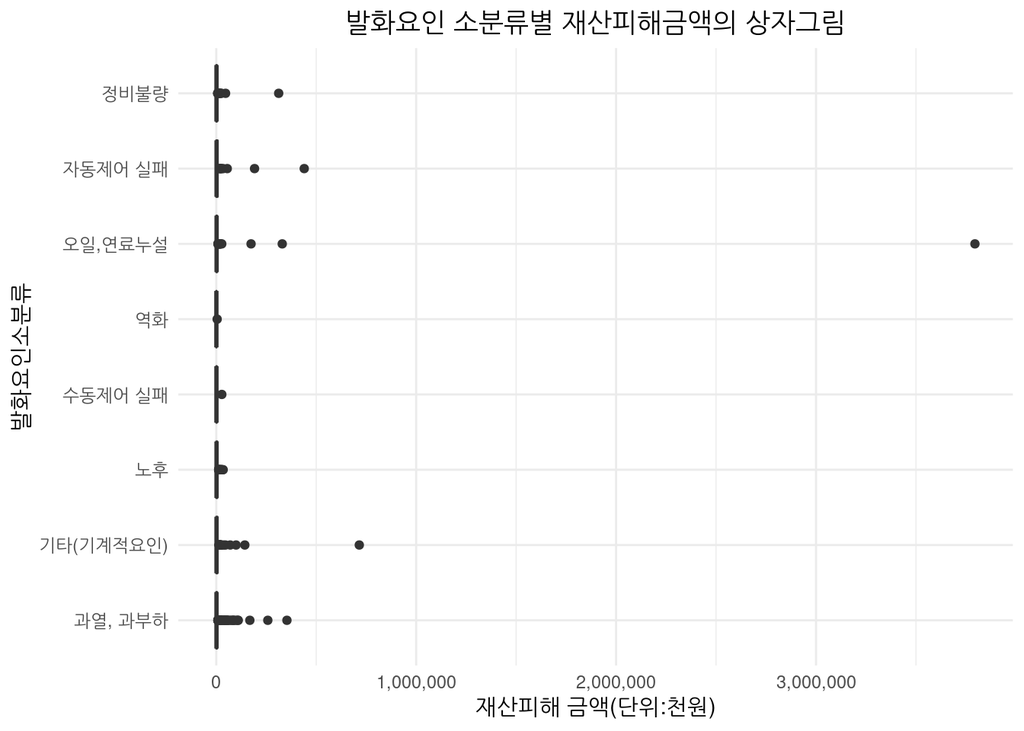

```r
# 화재원인별 재산피해 상자그림 ----
fire %>%
  filter(발화요인대분류 == "기계적 요인") %>%
  ggplot(aes(x = 발화요인소분류, y = 재산피해소계)) +
  geom_boxplot() +
  coord_flip() +
  labs(title = "발화요인 소분류별 재산피해금액의 상자그림") +
  ylab("재산피해 금액(단위:천원)") +
  theme_minimal() +
  theme(plot.title = element_text(hjust = 0.5)) +
  scale_y_continuous(labels=comma)
```

```r
# 화재원인별 재산피해액 기초통계량 ----
fire %>%
  filter(발화요인대분류 == "기계적 요인") %>%
  group_by(발화요인소분류) %>%
  summarise(건수 = n(),
              재산피해평균 = round(mean(재산피해소계), 1),
              재산피해표준편차 = round(sd(재산피해소계), 1),
              `재산피해하위25%` = quantile(재산피해소계, 0.25),
              `재산피해하위50%` = quantile(재산피해소계, 0.50),
              `재산피해상위25%` = quantile(재산피해소계, 0.75), .groups = 'drop') %>%
  arrange(-건수) %>%
  kable(caption = "발화요인 소분류별 재산피해액의 기초통계량",
        align = "lrrrrrr",
        digits = 1,
        format.args = list(big.mark = ",", scientific = FALSE))
```

발화요인 소분류별 재산피해액의 기초통계량

| 발화요인소분류 | 건수 | 재산피해평균 | 재산피해표준편차 | 재산피해하위25% | 재산피해하위50% | 재산피해상위25% |
| --- | --- | --- | --- | --- | --- | --- |
| 과열, 과부하 | 732 | 5,202.9 | 20,331.9 | 275.0 | 1,095.5 | 3,404.5 |
| 노후 | 178 | 3,781.0 | 5,837.6 | 331.8 | 1,355.5 | 4,697.5 |
| 기타(기계적요인) | 139 | 11,651.4 | 62,404.7 | 376.0 | 1,277.0 | 5,553.5 |
| 오일,연료누설 | 113 | 41,182.6 | 357,983.7 | 594.0 | 1,650.0 | 3,685.0 |
| 정비불량 | 98 | 6,104.4 | 31,836.5 | 288.0 | 1,138.0 | 2,875.5 |
| 자동제어 실패 | 60 | 15,860.5 | 61,384.0 | 247.8 | 1,553.5 | 6,336.0 |
| 수동제어 실패 | 13 | 3,415.5 | 7,398.9 | 558.0 | 892.0 | 2,541.0 |
| 역화 | 12 | 1,008.2 | 1,217.7 | 279.8 | 577.5 | 1,223.5 |

#### 다. 출동 소방서별 재산피해액의 분포

출동 소방서별 재산피해액에서는 이상치 유무에 따라서 평균 차이를 확인할 수 있다. 평균 재산피해 1천만원 이상 소방관서는 김해동부, 김해서부, 양산, 거창 소방서로 들 수 있는데, 상자그림에서 볼 수 있듯이 10억 이상 화재가 관측된다. 평균 재산피해액은 재산피해가 큰 화재의 유무에 따라 영향을 받는다고 볼 수도 있다.

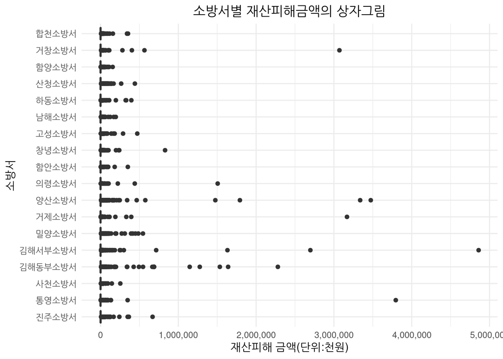

```r
# 소방서인별 재산피해 상자그림 ----
fire %>%
  ggplot(aes(x = 소방서, y = 재산피해소계)) +
  geom_boxplot() +
  coord_flip() +
  labs(title = "소방서별 재산피해금액의 상자그림") +
  ylab("재산피해 금액(단위:천원)") +
  theme_minimal() +
  theme(plot.title = element_text(hjust = 0.5)) +
  scale_y_continuous(labels=comma)
```

```r
# 화재원인별 재산피해액 기초통계량 ----
fire %>%
  group_by(소방서) %>%
  summarise(건수 = n(),
              재산피해평균 = round(mean(재산피해소계), 1),
              재산피해표준편차 = round(sd(재산피해소계), 1),
              `재산피해하위25%` = quantile(재산피해소계, 0.25),
              `재산피해하위50%` = quantile(재산피해소계, 0.50),
              `재산피해상위25%` = quantile(재산피해소계, 0.75), .groups = 'drop') %>%
  kable(caption = "소방서별 재산피해액의 기초통계량",
        align = "lrrrrrr",
        digits = 1,
        format.args = list(big.mark = ",", scientific = FALSE))
```

소방서별 재산피해액의 기초통계량

| 소방서 | 건수 | 재산피해평균 | 재산피해표준편차 | 재산피해하위25% | 재산피해하위50% | 재산피해상위25% |
| --- | --- | --- | --- | --- | --- | --- |
| 진주소방서 | 1,301 | 5,923.0 | 26,960.9 | 187.0 | 1,004.0 | 3,965.0 |
| 통영소방서 | 717 | 9,962.9 | 142,788.3 | 22.0 | 210.0 | 1,763.0 |
| 사천소방서 | 685 | 3,756.4 | 13,769.8 | 66.0 | 585.0 | 2,420.0 |
| 김해동부소방서 | 1,265 | 14,825.7 | 112,702.9 | 39.0 | 436.0 | 3,058.0 |
| 김해서부소방서 | 1,288 | 13,175.0 | 163,566.8 | 39.8 | 463.0 | 2,870.8 |
| 밀양소방서 | 1,056 | 6,829.7 | 36,613.4 | 0.8 | 436.5 | 2,715.2 |
| 거제소방서 | 1,068 | 6,407.7 | 98,624.5 | 14.0 | 176.5 | 1,402.0 |
| 양산소방서 | 1,191 | 15,257.5 | 157,412.5 | 48.5 | 605.0 | 3,300.5 |
| 의령소방서 | 473 | 7,596.4 | 73,217.7 | 0.0 | 220.0 | 1,981.0 |
| 함안소방서 | 878 | 3,669.0 | 15,879.0 | 0.0 | 396.0 | 2,097.5 |
| 창녕소방서 | 695 | 5,245.4 | 35,686.8 | 59.0 | 450.0 | 2,196.0 |
| 고성소방서 | 629 | 5,245.1 | 26,075.4 | 9.0 | 327.0 | 2,013.0 |
| 남해소방서 | 481 | 4,234.9 | 15,557.9 | 0.0 | 206.0 | 2,239.0 |
| 하동소방서 | 598 | 5,522.2 | 28,081.6 | 2.2 | 228.0 | 1,626.5 |
| 산청소방서 | 586 | 7,285.5 | 28,476.9 | 26.2 | 389.5 | 3,167.5 |
| 함양소방서 | 606 | 4,843.5 | 15,088.0 | 11.0 | 165.0 | 1,652.2 |
| 거창소방서 | 571 | 11,360.5 | 132,335.5 | 66.0 | 636.0 | 3,647.0 |
| 합천소방서 | 635 | 6,180.6 | 26,644.7 | 63.0 | 499.0 | 3,348.5 |

#### 라. 도착 시간대별 재산피해액의 분포

##### 1) 분단위 도착시간의 건수

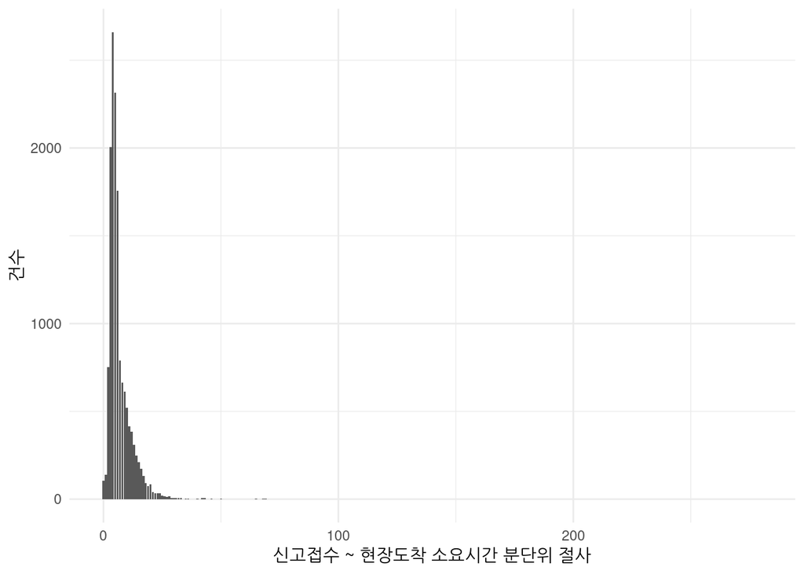

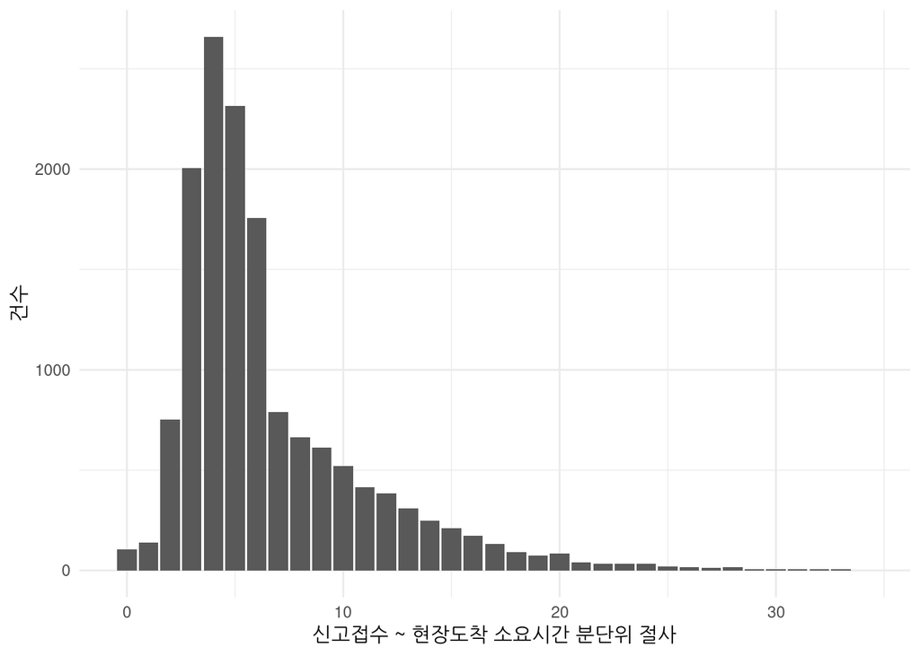

```r
fire %>%
  mutate(접수도착분 = trunc(difftime(도착일시, 접수일시, units = "mins"))) %>%
  select(접수일시, 도착일시, 접수도착분) %>%
  arrange(-접수도착분) %>%
  ggplot(aes(x = as.numeric(접수도착분))) +
  geom_bar() +
  theme_minimal() +
  xlab("신고접수 ~ 현장도착 소요시간 분단위 절사") +
  ylab("건수")

fire %>%
  mutate(접수도착분 = trunc(difftime(도착일시, 접수일시, units = "mins"))) %>%
  filter(접수도착분 < 35) %>%
  select(접수일시, 도착일시, 접수도착분) %>%
  arrange(-접수도착분) %>%
  ggplot(aes(x = as.numeric(접수도착분))) +
  geom_bar() +
  theme_minimal() +
  xlab("신고접수 ~ 현장도착 소요시간 분단위 절사") +
  ylab("건수")
```

##### 2) 신고 접수 분단위 시간대별 재산피해 분포

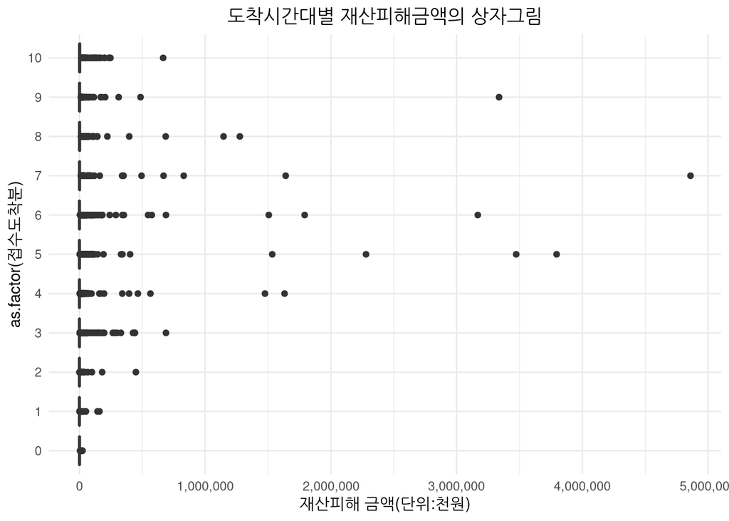

```r
fire %>%
  mutate(접수도착분 = trunc(difftime(도착일시, 접수일시, units = "mins"))) %>%
  filter(접수도착분 < 11) %>%
  ggplot(aes(x = as.factor(접수도착분), y = 재산피해소계)) +
  geom_boxplot() +
  coord_flip() +
  labs(title = "도착시간대별 재산피해금액의 상자그림") +
  ylab("재산피해 금액(단위:천원)") +
  theme_minimal() +
  theme(plot.title = element_text(hjust = 0.5)) +
  scale_y_continuous(labels=comma)
```

```r
fire %>%
  mutate(접수도착분 = trunc(difftime(도착일시, 접수일시, units = "mins"))) %>%
  group_by(접수도착분) %>%
  filter(접수도착분 < 11) %>%
  summarise(건수 = n(),
              재산피해평균 = round(mean(재산피해소계), 1),
              재산피해표준편차 = round(sd(재산피해소계), 1),
              `재산피해하위25%` = quantile(재산피해소계, 0.25),
              `재산피해하위50%` = quantile(재산피해소계, 0.50),
              `재산피해상위25%` = quantile(재산피해소계, 0.75), .groups = 'drop') %>%
  kable(caption = "도착시간대별 재산피해액의 기초통계량",
        align = "lrrrrrr",
        digits = 1,
        format.args = list(big.mark = ",", scientific = FALSE))
```

도착시간대별 재산피해액의 기초통계량

| 접수도착분 | 건수 | 재산피해평균 | 재산피해표준편차 | 재산피해하위25% | 재산피해하위50% | 재산피해상위25% |
| --- | --- | --- | --- | --- | --- | --- |
| 0 mins | 106 | 2,268.6 | 4,373.2 | 202.0 | 747 | 2,169.0 |
| 1 mins | 139 | 4,164.4 | 19,228.8 | 0.0 | 22 | 719.0 |
| 2 mins | 751 | 2,480.8 | 18,560.1 | 0.0 | 55 | 848.5 |
| 3 mins | 2,006 | 4,300.9 | 28,670.7 | 5.0 | 116 | 1,194.0 |
| 4 mins | 2,660 | 4,745.8 | 47,007.5 | 11.0 | 170 | 1,625.2 |
| 5 mins | 2,316 | 8,272.6 | 122,121.3 | 11.8 | 243 | 1,805.5 |
| 6 mins | 1,756 | 9,541.4 | 99,181.0 | 40.0 | 411 | 2,448.2 |
| 7 mins | 789 | 17,362.5 | 188,456.7 | 139.0 | 902 | 4,621.0 |
| 8 mins | 662 | 11,888.5 | 74,846.1 | 205.0 | 1,233 | 5,505.2 |
| 9 mins | 612 | 13,215.7 | 137,753.8 | 212.0 | 1,011 | 4,658.0 |
| 10 mins | 519 | 11,412.4 | 41,510.9 | 259.0 | 1,590 | 6,286.5 |

그 결과 선형성이 명확하게 나타나지는 않지만, 평균 금액은 6분 이후 5,869천원의 평균 재산피해가 발생하고 10분 대 11,412천원의 평균 재산피해가 나타나는 등 평균 재산피해금액이 증가하는 것은 보였다.

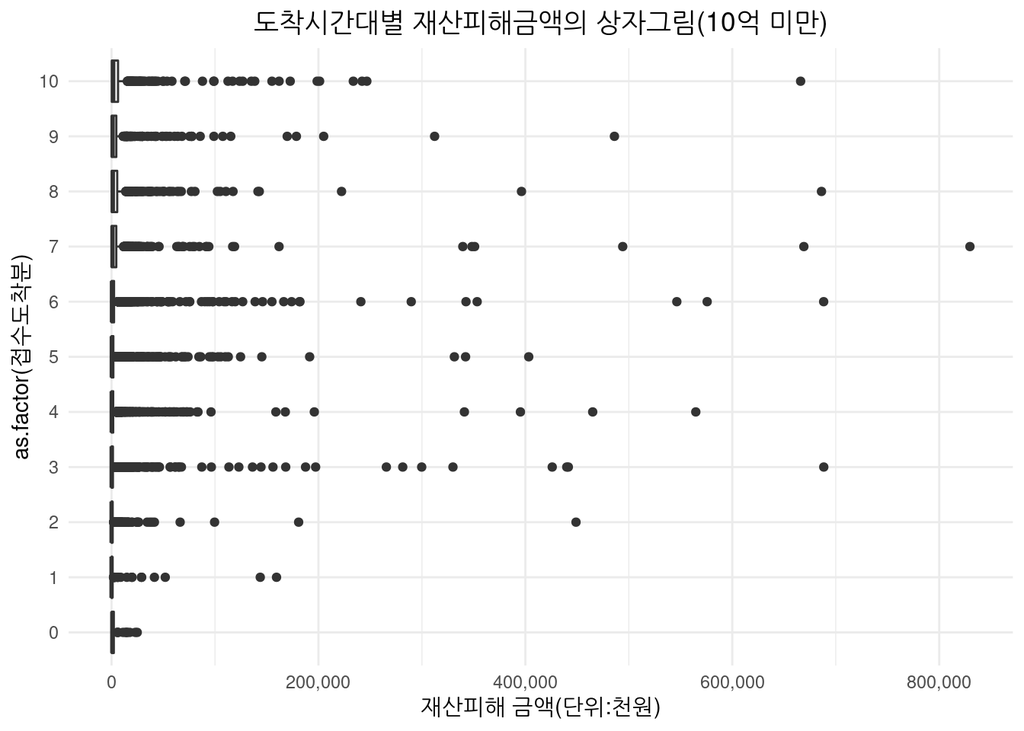

```r
fire %>%
  mutate(접수도착분 = trunc(difftime(도착일시, 접수일시, units = "mins"))) %>%
  filter(접수도착분 < 11) %>%
  filter(재산피해소계 < 1000000) %>%
  ggplot(aes(x = as.factor(접수도착분), y = 재산피해소계)) +
  geom_boxplot() +
  coord_flip() +
  labs(title = "도착시간대별 재산피해금액의 상자그림(10억 미만)") +
  ylab("재산피해 금액(단위:천원)") +
  theme_minimal() +
  theme(plot.title = element_text(hjust = 0.5)) +
  scale_y_continuous(labels=comma)
```

```r
fire %>%
  mutate(접수도착분 = trunc(difftime(도착일시, 접수일시, units = "mins"))) %>%
  group_by(접수도착분) %>%
  filter(접수도착분 < 11) %>%
  filter(재산피해소계 < 1000000) %>%
  summarise(건수 = n(),
              재산피해평균 = round(mean(재산피해소계), 1),
              재산피해표준편차 = round(sd(재산피해소계), 1),
              `재산피해하위25%` = quantile(재산피해소계, 0.25),
              `재산피해하위50%` = quantile(재산피해소계, 0.50),
              `재산피해상위25%` = quantile(재산피해소계, 0.75), .groups = 'drop') %>%
  kable(caption = "도착시간대별 재산피해액의 기초통계량(10억 미만)",
        align = "lrrrrrr",
        digits = 1,
        format.args = list(big.mark = ",", scientific = FALSE))
```

도착시간대별 재산피해액의 기초통계량(10억 미만)

| 접수도착분 | 건수 | 재산피해평균 | 재산피해표준편차 | 재산피해하위25% | 재산피해하위50% | 재산피해상위25% |
| --- | --- | --- | --- | --- | --- | --- |
| 0 mins | 106 | 2,268.6 | 4,373.2 | 202.0 | 747.0 | 2,169.0 |
| 1 mins | 139 | 4,164.4 | 19,228.8 | 0.0 | 22.0 | 719.0 |
| 2 mins | 751 | 2,480.8 | 18,560.1 | 0.0 | 55.0 | 848.5 |
| 3 mins | 2,006 | 4,300.9 | 28,670.7 | 5.0 | 116.0 | 1,194.0 |
| 4 mins | 2,658 | 3,580.4 | 19,993.1 | 11.0 | 169.5 | 1,619.8 |
| 5 mins | 2,312 | 3,494.0 | 16,661.2 | 11.0 | 241.0 | 1,772.0 |
| 6 mins | 1,753 | 5,869.7 | 32,498.8 | 40.0 | 410.0 | 2,439.0 |
| 7 mins | 787 | 9,147.2 | 48,509.2 | 138.5 | 898.0 | 4,604.0 |
| 8 mins | 660 | 8,254.8 | 35,058.7 | 203.5 | 1,222.5 | 5,500.0 |
| 9 mins | 611 | 7,775.2 | 29,382.2 | 211.0 | 1,009.0 | 4,629.5 |
| 10 mins | 519 | 11,412.4 | 41,510.9 | 259.0 | 1,590.0 | 6,286.5 |

##### 3) 도착시간(분) 과 재산피해액의 산점도

현장 도착시간(x축)과 재산피해액의 산점도에서는 소요시간에 따라 재산피해 금액이 증가하는 선형성은 보이지 않는다. 우리가 일반적으로 생각할 때 소요시간이 많이 걸릴 수록 재산피해가 증가 할 것으로 생각되지만 아래의 산점도를 보면 꼭 소요시간이 오래 걸린다고 재산피해가 증가하는 양의 선형관계를 나타내지는 않는다.

데이터의 분포가 25분 이내에 많이 몰려 있고, 재산피해 금액은 2억원 아래의 데이터가 많이 분포되어 있으며, 재산피해가 큰 금액도 도착시간 25분 이내에 분포해 있어 평균 재산피해금액이 크게 나타난 것으로 보인다.

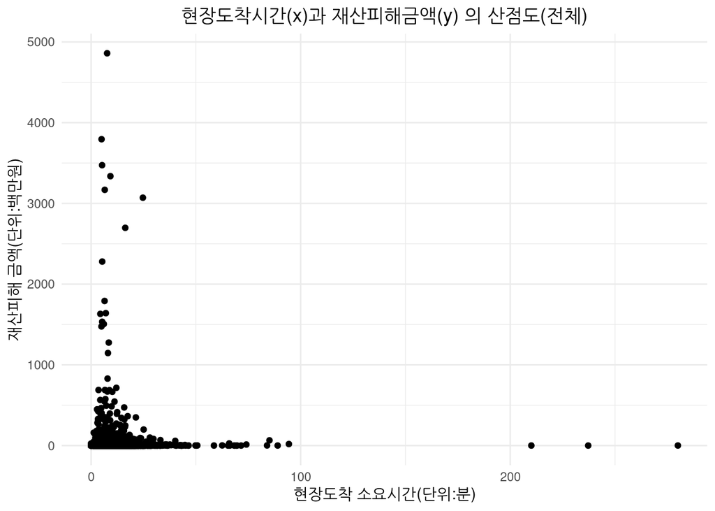

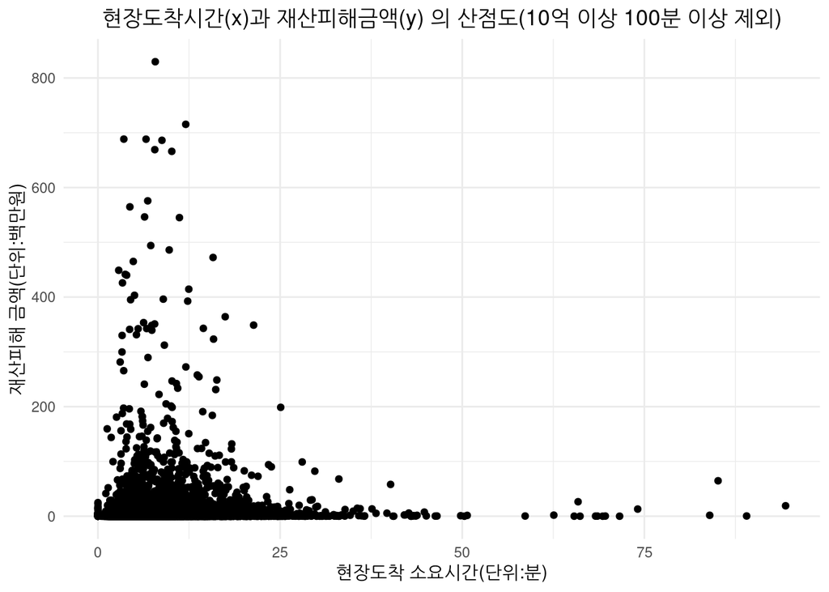

```r
fire %>%
  mutate(접수도착분 = difftime(도착일시, 접수일시, units = "mins")) %>%
  ggplot(aes(x = as.numeric(접수도착분), y = 재산피해소계/1000)) +
  geom_point() +
  labs(title = "현장도착시간(x)과 재산피해금액(y) 의 산점도(전체)") +
  ylab("재산피해 금액(단위:백만원)") +
  xlab("현장도착 소요시간(단위:분)") +
  theme_minimal() +
  theme(plot.title = element_text(hjust = 0.5))

fire %>%
  mutate(접수도착분 = difftime(도착일시, 접수일시, units = "mins")) %>%
  filter(접수도착분 < 100 & 재산피해소계 < 1000000) %>%
  ggplot(aes(x = as.numeric(접수도착분), y = 재산피해소계/1000)) +
  geom_point() +
  labs(title = "현장도착시간(x)과 재산피해금액(y) 의 산점도(10억 이상 100분 이상 제외)") +
  ylab("재산피해 금액(단위:백만원)") +
  xlab("현장도착 소요시간(단위:분)") +
  theme_minimal() +
  theme(plot.title = element_text(hjust = 0.5))
```

##### 4) 주거시설 화재의 도착시간(분) 과 재산피해액의 산점도

화재 유형별 재산피해액의 분포에서 화재 유형에 따라 재산피해금액이 다양하게 나타났기 때문에, 재산피해가 너무 적은 임야, 기타화재와 재산피해가 너무 많은 선박 항공기, 위험물 화재를 제외한 주거시설의 화재 데이터만 활용하여 도착시간과 재산피해액의 산점도를 그려보았다.

데이터의 분포를 쉽게 보기 위하여 좌측은 전체 데이터를, 우측은 재산피해 10억 이상 도착시간 100분 이상 데이터는 제외한 산점도이다.

주거시설의 데이터만 보더라도, 현장도착 소요시간 증가에 따라 재산피해 금액의 증가의 선형성이 뚜렸하게 나타나지는 않는다.

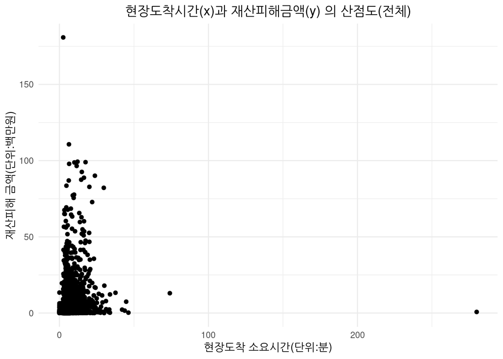

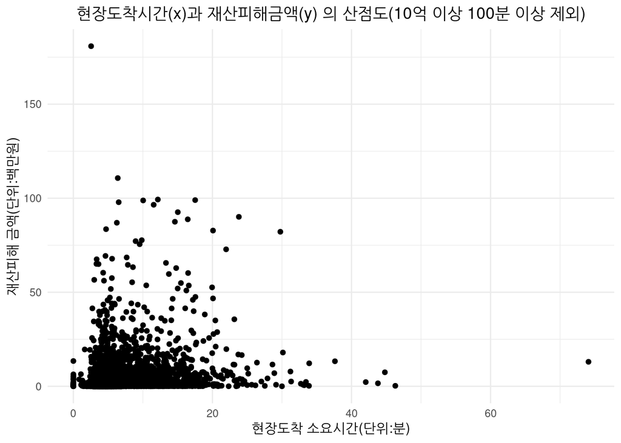

```r
fire %>%
  filter(장소대분류 == "주거") %>%
  mutate(접수도착분 = difftime(도착일시, 접수일시, units = "mins")) %>%
  ggplot(aes(x = as.numeric(접수도착분), y = 재산피해소계/1000)) +
  geom_point() +
  labs(title = "현장도착시간(x)과 재산피해금액(y) 의 산점도(전체)") +
  ylab("재산피해 금액(단위:백만원)") +
  xlab("현장도착 소요시간(단위:분)") +
  theme_minimal() +
  theme(plot.title = element_text(hjust = 0.5))

fire %>%
  filter(장소대분류 == "주거") %>%
  mutate(접수도착분 = difftime(도착일시, 접수일시, units = "mins")) %>%
  filter(접수도착분 < 100 & 재산피해소계 < 1000000) %>%
  ggplot(aes(x = as.numeric(접수도착분), y = 재산피해소계/1000)) +
  geom_point() +
  labs(title = "현장도착시간(x)과 재산피해금액(y) 의 산점도(10억 이상 100분 이상 제외)") +
  ylab("재산피해 금액(단위:백만원)") +
  xlab("현장도착 소요시간(단위:분)") +
  theme_minimal() +
  theme(plot.title = element_text(hjust = 0.5))
```

##### 5) 도착 시간대별 1000만원 이상 화재의 비율 비교

상기 과정에서 시간대별 재산피해액의 뚜렷한 선형관계는 보이지 않았지만, 분단위 시간대별 평균 재산피애액의 차이는 보였다. 이는 도착 시간의 증가는 재산피해액 증가의 필요조건이라고 보기는 어렵지만 충분조건이라고 볼 수는 있을 것이다. 다르게 말하면 현장도착시간이 늘어난다고 해서 재산피해 금액이 늘어나지는 않지만 재산피해가 발생할 가능성이 커진다고 볼 수 있다. 따라서 우리는 평균 재산피해액보다 조금 높은 수준인 1천만원 이상 화재의 비율에 포커스를 두어 1천만원 이상의 재산피해가 발생할 확률이 어떻게 달라지는 지 알아보기로 하였다.

도착시간 15분 대까지의 재산피해 1천만원 이상의 비율을 보면 7분 아래까지 8.09% 이하였다가, 7분이 초과하면서 1천만원 이상의 화재가 발생할 확률은 13.18%로 증가하는 것을 볼 수 있다.

```r
fire %>%
  mutate(천만원이상 = if_else(재산피해소계 >= 10000, "천만원이상", "천만원미만"),
              접수도착분 = trunc(difftime(도착일시, 접수일시, units = "mins"))) %>%
  filter(접수도착분 <= 15) %>%
  select(천만원이상, 접수도착분) %>%
  count(접수도착분, 천만원이상) %>%
  reshape2::dcast(접수도착분 ~ 천만원이상, fill = 0, value.var = "n") %>%
  mutate(`천만원이상비율(%)` = round(100*천만원이상/(천만원이상 + 천만원미만), 4)) %>%
  kable(caption = "도착시간(분)대별 천만원 이상 이하 건수와 비율",
        align = "rrrr",
        digits = 2,
        format.args = list(big.mark = ",", scientific = FALSE))
```

도착시간(분)대별 천만원 이상 이하 건수와 비율

| 접수도착분 | 천만원미만 | 천만원이상 | 천만원이상비율(%) |
| --- | --- | --- | --- |
| 0 mins | 99 | 7 | 6.60 |
| 1 mins | 130 | 9 | 6.47 |
| 2 mins | 724 | 27 | 3.60 |
| 3 mins | 1,894 | 112 | 5.58 |
| 4 mins | 2,483 | 177 | 6.65 |
| 5 mins | 2,168 | 148 | 6.39 |
| 6 mins | 1,614 | 142 | 8.09 |
| 7 mins | 685 | 104 | 13.18 |
| 8 mins | 559 | 103 | 15.56 |
| 9 mins | 527 | 85 | 13.89 |
| 10 mins | 417 | 102 | 19.65 |
| 11 mins | 369 | 45 | 10.87 |
| 12 mins | 333 | 51 | 13.28 |
| 13 mins | 262 | 46 | 14.94 |
| 14 mins | 211 | 37 | 14.92 |
| 15 mins | 177 | 35 | 16.51 |

상기 과정에서 데이터를 조금 변경하여 범주형 자료 분석기법을 적용하였다. 7분대 미만 집단에서의 천만원 이상 비율은 6.4%이고, 7분대 이상에서의 천만원 이상 비율은 14.7%로 나타났다.

```r
chisq <- fire %>%
  mutate(천만원이상 = if_else(재산피해소계 >= 10000, "천만원이상", "천만원미만"),
              접수도착분 = if_else(difftime(도착일시, 접수일시, units = "mins") < 7, "7분대 미만", "7분대 이상")) %>%
  select(천만원이상, 접수도착분)


fire %>%
  mutate(천만원이상 = if_else(재산피해소계 >= 10000, "천만원이상", "천만원미만"),
              접수도착분 = if_else(difftime(도착일시, 접수일시, units = "mins") < 7, "7분대 미만", "7분대 이상")) %>%
  select(천만원이상, 접수도착분) %>%
  count(접수도착분, 천만원이상) %>%
  group_by(접수도착분) %>%
  mutate(비율 = round(100*n/sum(n), 1)) %>%
  select(-n) %>%
  reshape2::dcast(접수도착분 ~ 천만원이상, value.var = "비율", sum, margins = "천만원이상") %>%
  kable(caption = "골든타임 도착유무와 재산피해 천만원이상 비율",
        align = "lrrr",
        digits = 1,
        format.args = list(big.mark = ",", scientific = FALSE))
```

골든타임 도착유무와 재산피해 천만원이상 비율

| 접수도착분 | 천만원미만 | 천만원이상 | (all) |
| --- | --- | --- | --- |
| 7분대 미만 | 93.6 | 6.4 | 100 |
| 7분대 이상 | 85.3 | 14.7 | 100 |

```r
fire %>%
  mutate(천만원이상 = if_else(재산피해소계 >= 10000, "천만원이상", "천만원미만"),
              접수도착분 = if_else(difftime(도착일시, 접수일시, units = "mins") < 7, "7분대 미만", "7분대 이상")) %>%
  select(천만원이상, 접수도착분) %>%
  count(접수도착분, 천만원이상) %>%
  group_by(접수도착분) %>%
  rename(건수 = n) %>%
  reshape2::dcast(접수도착분 ~ 천만원이상, value.var = "건수", sum, margins = "천만원이상") %>%
  kable(caption = "골든타임 도착유무와 재산피해 천만원이상 건수",
        align = "lrrr",
        digits = 1,
        format.args = list(big.mark = ",", scientific = FALSE))
```

골든타임 도착유무와 재산피해 천만원이상 건수

| 접수도착분 | 천만원미만 | 천만원이상 | (all) |
| --- | --- | --- | --- |
| 7분대 미만 | 9,112 | 622 | 9,734 |
| 7분대 이상 | 4,254 | 735 | 4,989 |

수치형 변수인 재산피해와 도착소요시간을 범주형 변수로 변경하고, 두 범주형 변수에서 관찰된 빈도가 기대 빈도와 의미있게 다른지를 검증하기 위한 카이제곱 검정 결과 p-value 는 0에 가까우므로, 천만원 이상 유무와 접수도착 7분이상 유무 두 변수는 서로 독립이라는 귀무가설을 기각할 수 있고, 7분 이상 유무에 따라 1천만원 이상 재산피해의 발생 비율이 다르다고 해석할 수 있다.

```r
# 카이제곱 검정 통계량 및 p-value

chisq_test(chisq, 천만원이상 ~ 접수도착분) %>%
  kable(caption = "카이제곱 통계량 및 p-value 표",
        align = "rrr",
        digits = 4,
        format.args = list(big.mark = ",", scientific = FALSE))
```

카이제곱 통계량 및 p-value 표

| statistic | chisq_df | p_value |
| --- | --- | --- |
| 273.3544 | 1 | 0 |

#### 마. 건축물 면적별 재산피해액의 분포

##### 1) 건축물 면적의 분포

화재유형이 건축, 구조물인 데이터 중 면적의 분포는 좌측과 같고, 연면적 50만㎡ 이상 데이터는 오타로 보고 제외 하였다.

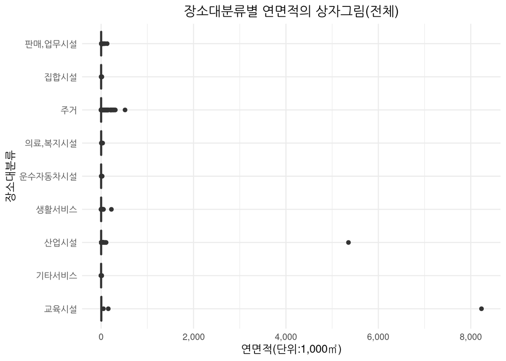

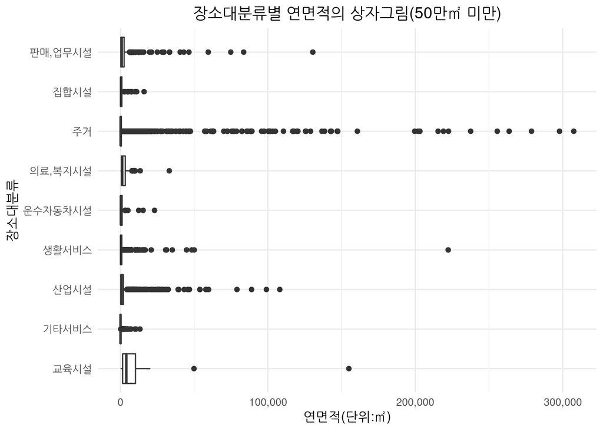

```r
fire %>%
  filter(화재유형 == "건축,구조물") %>%
  ggplot(aes(x = 연면적/1000, y = 장소대분류)) +
  geom_boxplot() +
  theme_minimal() +
  labs(title = "장소대분류별 연면적의 상자그림(전체)") +
  xlab("연면적(단위:1,000㎡)") +
  theme(plot.title = element_text(hjust = 0.5)) +
  scale_x_continuous(labels=comma)

fire %>%
  filter(화재유형 == "건축,구조물") %>%
  filter(연면적 < 500000) %>%
  ggplot(aes(x = 연면적, y = 장소대분류)) +
  geom_boxplot() +
  theme_minimal() +
  labs(title = "장소대분류별 연면적의 상자그림(50만㎡ 미만)") +
  xlab("연면적(단위:㎡)") +
  theme(plot.title = element_text(hjust = 0.5)) +
  scale_x_continuous(labels=comma)
```

##### 2) 건축물 면적과 재산피해의 산점도

건축물 면적과 재산피해액의 산점도에서 연면적 증가에 따른 재산피해 금액의 증가는 보이지 않는다.

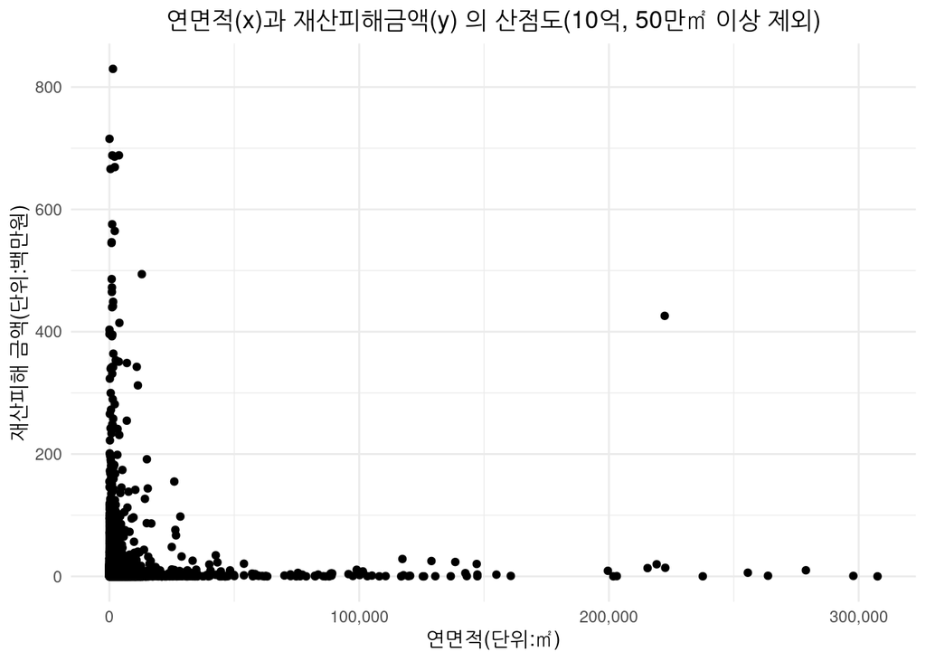

```r
fire %>%
  filter(연면적 < 500000 & 재산피해소계 < 1000000) %>%
  ggplot(aes(x = 연면적, y = 재산피해소계/1000)) +
  geom_point() +
  labs(title = "연면적(x)과 재산피해금액(y) 의 산점도(10억, 50만㎡ 이상 제외)") +
  ylab("재산피해 금액(단위:백만원)") +
  xlab("연면적(단위:㎡)") +
  theme_minimal() +
  theme(plot.title = element_text(hjust = 0.5)) +
  scale_x_continuous(labels=comma)
```

#### 바. 건축물 구조별 재산피해액의 분포

건물 구조별 재산피해금액의 상자그림을 보면, 철골철근콘크리트조 화재의 재산피해 평균이 가장 높은 것으로 나타 났는데 이는 63건의 화재 중 1건이 48억원의 재산피해가 나왔기 때문으로 보인다. 낮은 평균 재산피해를 보이는 구조는 블럭조, 컨테이너조, 기타 조 등 구축 건축물에서 주로 사용되는 구조로 보이고, 높은 평균 재산피해를 보이는 구조는 철근콘크리트조, 샌드위치패널조, 철골조 등 신축 건축물에서 주로 사용되는 구조를 보인다. 벽돌조와 철조 목조는 중위층 으로 구분되는 것을 알 수 있다.

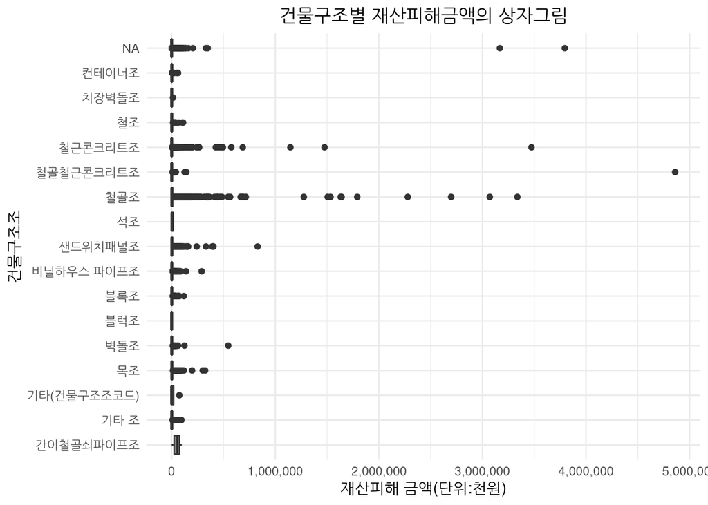

```r
fire %>%
  ggplot(aes(x = 건물구조조, y = 재산피해소계)) +
  geom_boxplot() +
  coord_flip() +
  labs(title = "건물구조별 재산피해금액의 상자그림") +
  ylab("재산피해 금액(단위:천원)") +
  theme_minimal() +
  theme(plot.title = element_text(hjust = 0.5)) +
  scale_y_continuous(labels=comma)
```

```r
fire %>%
  group_by(건물구조조) %>%
  summarise(건수 = n(),
              재산피해평균 = round(mean(재산피해소계), 1),
              재산피해표준편차 = round(sd(재산피해소계), 1),
              `재산피해하위25%` = quantile(재산피해소계, 0.25),
              `재산피해하위50%` = quantile(재산피해소계, 0.50),
              `재산피해상위25%` = quantile(재산피해소계, 0.75), .groups = 'drop') %>%
  arrange(-재산피해평균) %>%
  kable(caption = "건물구조별 재산피해액의 기초통계량",
        align = "lrrrrrr",
        digits = 1,
        format.args = list(big.mark = ",", scientific = FALSE))
```

건물구조별 재산피해액의 기초통계량

| 건물구조조 | 건수 | 재산피해평균 | 재산피해표준편차 | 재산피해하위25% | 재산피해하위50% | 재산피해상위25% |
| --- | --- | --- | --- | --- | --- | --- |
| 철골철근콘크리트조 | 63 | 85,271.8 | 611,731.5 | 148.0 | 879.0 | 3,840.0 |
| 간이철골쇠파이프조 | 2 | 48,986.0 | 69,149.4 | 24,538.0 | 48,986.0 | 73,434.0 |
| 철골조 | 1,397 | 35,414.5 | 194,823.4 | 515.0 | 2,148.0 | 9,845.0 |
| 기타(건물구조조코드) | 4 | 18,794.0 | 36,852.4 | 102.0 | 541.5 | 19,233.5 |
| 샌드위치패널조 | 504 | 15,145.5 | 56,845.6 | 632.0 | 2,296.5 | 8,579.8 |
| 석조 | 5 | 9,263.4 | 10,259.6 | 2,979.0 | 3,581.0 | 13,379.0 |
| 철근콘크리트조 | 2,671 | 8,368.1 | 81,831.3 | 83.0 | 543.0 | 3,050.0 |
| 목조 | 738 | 7,376.0 | 21,953.8 | 478.0 | 2,112.0 | 6,173.2 |
| 철조 | 126 | 6,837.8 | 16,301.7 | 386.5 | 1,097.5 | 4,565.2 |
| 벽돌조 | 440 | 6,792.7 | 28,222.0 | 250.2 | 1,080.0 | 4,919.5 |
| 비닐하우스 파이프조 | 647 | 5,128.8 | 15,185.4 | 565.0 | 1,633.0 | 4,692.5 |
| 블록조 | 682 | 5,126.2 | 10,089.4 | 295.0 | 1,475.0 | 5,548.0 |
| 기타 조 | 183 | 4,775.7 | 12,528.0 | 379.0 | 1,210.0 | 3,946.5 |
| NA | 6,935 | 2,774.6 | 60,048.4 | 0.0 | 55.0 | 625.5 |
| 치장벽돌조 | 18 | 2,563.6 | 3,618.7 | 179.5 | 822.5 | 3,333.8 |
| 컨테이너조 | 305 | 2,507.8 | 4,959.0 | 505.0 | 1,467.0 | 2,764.0 |
| 블럭조 | 3 | 954.7 | 1,377.7 | 165.0 | 330.0 | 1,432.0 |

### 4. 인명피해와 연관성 있는 변수 탐색

#### 가. 화재유형별 인명피해의 분포

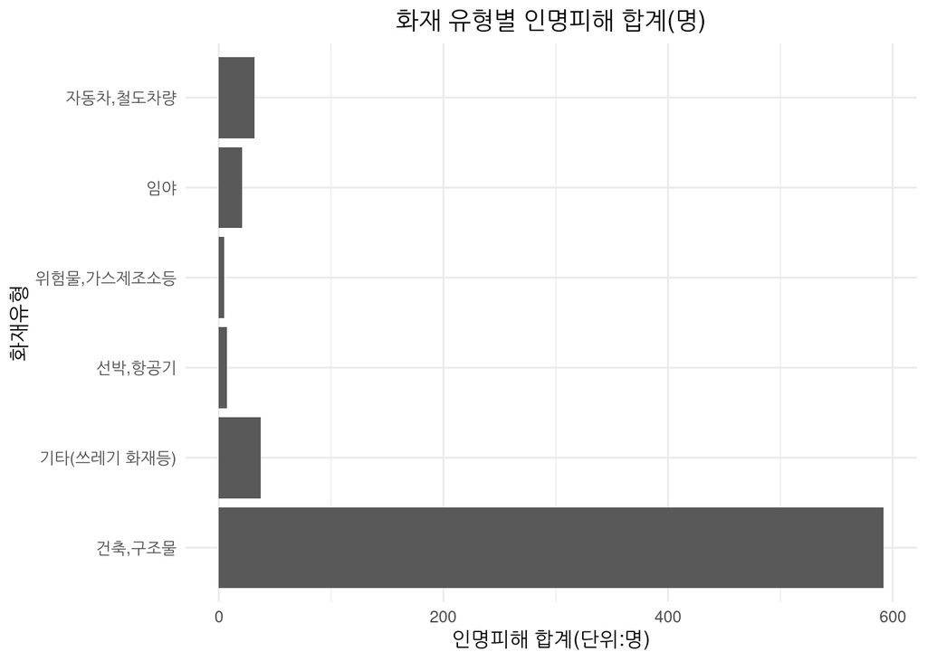

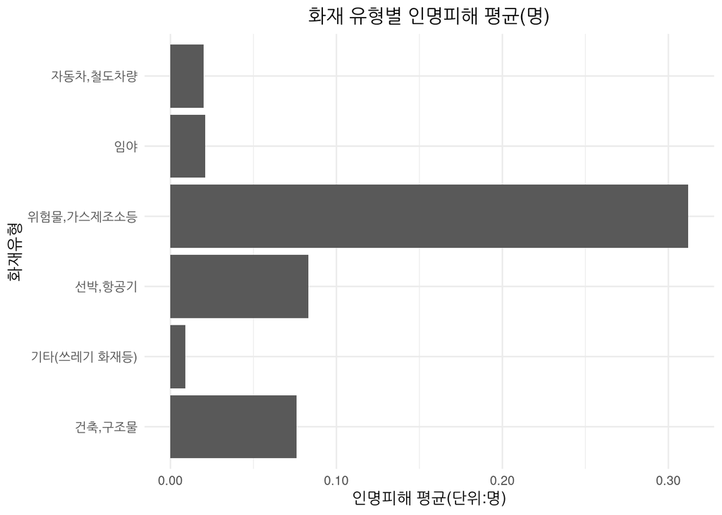

```r
fire %>%
  group_by(화재유형) %>%
  summarise(건수 = n(),
              인명피해합계 = sum(`인명피해(명)소계`),
              인명피해평균 = round(mean(`인명피해(명)소계`), 3),
              .groups = 'drop') %>%
  ggplot(aes(x = 화재유형, y = 인명피해합계)) +
  geom_bar(stat = "identity") +
  coord_flip() +
  labs(title = "화재 유형별 인명피해 합계(명)") +
  ylab("인명피해 합계(단위:명)") +
  theme_minimal() +
  theme(plot.title = element_text(hjust = 0.5)) +
  scale_y_continuous(labels=comma)


fire %>%
  group_by(화재유형) %>%
  summarise(건수 = n(),
              인명피해합계 = sum(`인명피해(명)소계`),
              인명피해평균 = round(mean(`인명피해(명)소계`), 3),
              .groups = 'drop') %>%
  ggplot(aes(x = 화재유형, y = 인명피해평균)) +
  geom_bar(stat = "identity") +
  coord_flip() +
  labs(title = "화재 유형별 인명피해 평균(명)") +
  ylab("인명피해 평균(단위:명)") +
  theme_minimal() +
  theme(plot.title = element_text(hjust = 0.5)) +
  scale_y_continuous(labels=comma)
```

```r
fire %>%
  group_by(화재유형) %>%
  summarise(건수 = n(),
              인명피해합계 = sum(`인명피해(명)소계`),
              인명피해평균 = round(mean(`인명피해(명)소계`), 3),
              .groups = 'drop') %>%
  arrange(-건수) %>%
  kable(caption = "화재유형별 인명피해의 기초통계량",
        align = "lrrr",
        digits = 3,
        format.args = list(big.mark = ",", scientific = FALSE))
```

화재유형별 인명피해의 기초통계량

| 화재유형 | 건수 | 인명피해합계 | 인명피해평균 |
| --- | --- | --- | --- |
| 건축,구조물 | 7,772 | 592 | 0.076 |
| 기타(쓰레기 화재등) | 4,283 | 37 | 0.009 |
| 자동차,철도차량 | 1,566 | 32 | 0.020 |
| 임야 | 1,002 | 21 | 0.021 |
| 선박,항공기 | 84 | 7 | 0.083 |
| 위험물,가스제조소등 | 16 | 5 | 0.312 |